# Cyclability scores

```python
import csv
import sys
import pprint
import numpy as np
import pandas as pd
from scipy import stats
import psycopg2
import psycopg2.extras
import seaborn as seab
import matplotlib.pyplot as plt
import geopandas
from descartes.patch import PolygonPatch
import rtree
import fiona
import shapely
```

# Loading the data

This uses code provided in the DATA2001 Lab 4 worksheet.

```python
def pgconnect():
    YOUR_UNIKEY = 'jski0529'
    YOUR_PW     = '480377111'
    try:
        conn = psycopg2.connect(host='soit-db-pro-1.ucc.usyd.edu.au',
                                database='y19s1d2x01_'+YOUR_UNIKEY,
                                user='y19s1d2x01_'+YOUR_UNIKEY,
                                password=YOUR_PW)
        print('connected')
    except Exception as e:
        print("unable to connect to the database")
        print(e)
        return None
    return conn

def pgexec( conn, sqlcmd, args, msg, silent=False ):
   """ utility function to execute some SQL statement
       can take optional arguments to fill in (dictionary)
       error and transaction handling built-in """
   retval = False
   with conn:
      with conn.cursor() as cur:
         try:
            if args is None:
               cur.execute(sqlcmd)
            else:
               cur.execute(sqlcmd, args)
            if silent == False:
                print("success: " + msg)
            retval = True
         except Exception as e:
            if silent == False:
                print("db error: ")
                print(e)
   return retval

def pgquery( conn, sqlcmd, args=None, msg=False, returntype='tuple'):
    """ utility function to execute some SQL query statement
        it can take optional arguments (as a dictionary) to fill in for placeholders in the SQL
        will return the complete query result as return value - or in case of error: None
        error and transaction handling built-in (by using the 'with' clauses)"""
    retval = None
    with conn:
        cursortype = None if returntype != 'dict' else psycopg2.extras.RealDictCursor
        with conn.cursor(cursor_factory=cursortype) as cur:
            try:
                if args is None:
                    cur.execute(sqlcmd)
                else:
                    cur.execute(sqlcmd, args)
                if (cur.description != None ):
                    retval = cur.fetchall() # we use fetchall() as we expect only _small_ query results
                if msg != False:
                    print("success: " + msg)
            except psycopg2.DatabaseError as e:
                if e.pgcode != None and msg:
                    print("db read error: "+msg)
                    print(e)
            except Exception as e:
                print(e)
    return retval

# Connecting
conn = pgconnect()
```

```
connected
```

```python
DEFAULT_VALUE = 0 #'Null'

def clean(data, column_key, convert_function, default_value):
    special_values= {} # no special values yet
    for row in data:
        old_value = row[column_key]
        new_value = default_value
        try:
            if old_value in special_values.keys():
                new_value = special_values[old_value]
            else:
                new_value = convert_function(old_value)
        except (ValueError, TypeError):
            print('Replacing {} with {} in column {}'.format(row[column_key], new_value, column_key))
        row[column_key] = new_value
```

This code section was written to load all of the provided CSV files into the Python memory. The section directly below it is for cleaning the data. Written by Nikki Zhang

```python
# Storing data into memory
data_bike_sharing_pods = list(csv.DictReader(open('./Data/BikeSharingPods.csv')))
data_business_stats = list(csv.DictReader(open('./Data/BusinessStats.csv')))
data_census_stats = list(csv.DictReader(open('./Data/CensusStats.csv')))
data_neighbourhoods = list(csv.DictReader(open('./Data/Neighbourhoods.csv')))
data_statistical_areas = list(csv.DictReader(open('./Data/StatisticalAreas.csv')))
```

```python
clean(data_neighbourhoods, 'population', int, DEFAULT_VALUE)
clean(data_neighbourhoods, 'number_of_dwellings', int, DEFAULT_VALUE)
clean(data_neighbourhoods,'number_of_businesses',int,DEFAULT_VALUE)

clean(data_bike_sharing_pods, 'num_bikes', int, DEFAULT_VALUE)

clean(data_business_stats,'num_businesses',int,DEFAULT_VALUE)
clean(data_business_stats,'retail_trade',int,DEFAULT_VALUE)
clean(data_business_stats,'accommodation_and_food_services',int,DEFAULT_VALUE)
clean(data_business_stats,'health_care_and_social_assistance',int,DEFAULT_VALUE)
clean(data_business_stats,'education_and_training',int,DEFAULT_VALUE)
clean(data_business_stats,'arts_and_recreation_services',int,DEFAULT_VALUE)

clean(data_census_stats,'median_annual_household_income',int,DEFAULT_VALUE)
clean(data_census_stats,'avg_monthly_rent',int,DEFAULT_VALUE)
```

This is the schema for the 5 data tables from the CSV. Written by James Skibinski.

```python
# Writing the data to a database
## Building the schema for every database
bike_sharing_pods_schema = """DROP TABLE IF EXISTS BikeSharingPods;
                              CREATE TABLE IF NOT EXISTS BikeSharingPods(
                                  station_id NUMERIC PRIMARY KEY,
                                  name TEXT,
                                  num_bikes NUMERIC,
                                  num_scooters NUMERIC,
                                  latitude FLOAT,
                                  longitude FLOAT
                              )
                            """
business_stats_schema = """DROP TABLE IF EXISTS BusinessStats;
                              CREATE TABLE IF NOT EXISTS BusinessStats(
                                  area_id NUMERIC PRIMARY KEY,
                                  num_businesses NUMERIC,
                                  retail_trade NUMERIC,
                                  accommodation_and_food_services NUMERIC,
                                  health_care_and_social_assistance NUMERIC,
                                  education_and_training NUMERIC,
                                  arts_and_recreation_services NUMERIC
                              )
                            """
census_stats_schema = """DROP TABLE IF EXISTS CensusStats;
                              CREATE TABLE IF NOT EXISTS CensusStats(
                                  area_id NUMERIC PRIMARY KEY,
                                  median_annual_household_income NUMERIC,
                                  avg_monthly_rent NUMERIC
                              )
                            """
neighbourhoods_schema = """DROP TABLE IF EXISTS Neighbourhoods;
                              CREATE TABLE IF NOT EXISTS Neighbourhoods(
                                  area_id NUMERIC PRIMARY KEY,
                                  area_name TEXT,
                                  land_area NUMERIC,
                                  population NUMERIC,
                                  number_of_dwellings NUMERIC,
                                  number_of_businesses NUMERIC
                              )
                            """
statistical_areas_schema = """DROP TABLE IF EXISTS StatisticalAreas;
                              CREATE TABLE IF NOT EXISTS StatisticalAreas(
                                  area_id NUMERIC PRIMARY KEY,
                                  area_name TEXT,
                                  parent_area_id NUMERIC
                              )
                            """
```

Now this code creates the tables.

```python
## Creating the tables
pgexec (conn, bike_sharing_pods_schema, None, "Create Table BikeSharingPods", True)
pgexec (conn, business_stats_schema, None, "Create Table BusinessStats", True)
pgexec (conn, census_stats_schema, None, "Create Table CensusStats", True)
pgexec (conn, neighbourhoods_schema, None, "Create Table Neighbourhoods", True)
pgexec (conn, statistical_areas_schema, None, "Create Table StatisticalAreas", True)
```

This code is for populating the tables.

```python
# Bike sharing pods
insert_stmt_bike = """INSERT INTO BikeSharingPods(station_id,name,num_bikes,num_scooters,latitude,longitude)
VALUES (%(station_id)s, %(name)s, %(num_bikes)s, %(num_scooters)s, %(latitude)s, %(longitude)s)"""
for row in data_bike_sharing_pods:
    pgexec (conn, insert_stmt_bike, row, "row inserted", True)

# Business stats
insert_stmt_business = """INSERT INTO BusinessStats(area_id, num_businesses, retail_trade, accommodation_and_food_services, health_care_and_social_assistance, education_and_training, arts_and_recreation_services)
VALUES (%(area_id)s, %(num_businesses)s, %(retail_trade)s, %(accommodation_and_food_services)s, %(health_care_and_social_assistance)s, %(education_and_training)s, %(arts_and_recreation_services)s)"""
for row in data_business_stats:
    pgexec (conn, insert_stmt_business, row, "row inserted", True)

#Census stats
insert_stmt_census = """INSERT INTO CensusStats(area_id, median_annual_household_income, avg_monthly_rent)
VALUES (%(area_id)s, %(median_annual_household_income)s, %(avg_monthly_rent)s)"""
for row in data_census_stats:
    pgexec (conn, insert_stmt_census, row, "row inserted", True)

#Neighbourhoods
insert_stmt_neighbourhoods = """INSERT INTO Neighbourhoods(area_id, area_name, land_area, population, number_of_dwellings, number_of_businesses)
VALUES (%(area_id)s, %(area_name)s, %(land_area)s, %(population)s, %(number_of_dwellings)s, %(number_of_businesses)s)"""
for row in data_neighbourhoods:
    # So far, it excludes null values
    pgexec (conn, insert_stmt_neighbourhoods, row, "row inserted", True)

#Statistical areas
insert_stmt_statistical_areas = """INSERT INTO StatisticalAreas(area_id, area_name, parent_area_id)
VALUES (%(area_id)s, %(area_name)s, %(parent_area_id)s)"""
for row in data_statistical_areas:
    pgexec (conn, insert_stmt_statistical_areas, row, "row inserted", True)
```

## Loading extra data

This section used extra data taken from a 2017 Transport NSW road casualties report. The report was in pdf form. The relevant tables was converted into Word .docx format, cleaned and converted to HTML. The resulting HTML file was then cleaned further. Dimitri Hahlos was responsible for sourcing the data and processing it into a usable form.

```python
data = pd.read_html('./Data/Crashes Table.html',skiprows=1)[0]
data1 = pd.DataFrame(data)
data1.columns = ['LGA_NAME18','FC', 'SC', 'MC', 'OC', 'Total_casualty_crashes', 'K', 'S','M','O','Total_killed_&_injured']
dataframe_fatalities = data1.iloc[1:]
dataframe_fatalities
```

|  | LGA_NAME18 | FC | SC | MC | OC | Total_casualty_crashes | K | S | M | O | Total_killed_&_injured |
| --- | --- | --- | --- | --- | --- | --- | --- | --- | --- | --- | --- |
| 1 | Bayside | 5 | 121 | 187 | 179 | 492 | 5 | 134 | 237 | 233 | 609 |
| 2 | Blacktown | 7 | 298 | 118 | 218 | 641 | 7 | 339 | 166 | 302 | 814 |
| 3 | Burwood | 1 | 31 | 27 | 44 | 103 | 1 | 32 | 34 | 59 | 126 |
| 4 | Camden | 2 | 31 | 37 | 35 | 105 | 2 | 37 | 48 | 44 | 131 |
| 5 | Campbelltown | 1 | 91 | 79 | 78 | 249 | 1 | 100 | 100 | 114 | 315 |
| 6 | Canada Bay | 0 | 48 | 70 | 106 | 224 | 0 | 51 | 89 | 136 | 276 |
| 7 | Canterbury-Bankstown | 5 | 273 | 314 | 444 | 1036 | 5 | 298 | 419 | 608 | 1330 |
| 8 | Cumberland | 1 | 182 | 169 | 316 | 668 | 1 | 205 | 220 | 423 | 849 |
| 9 | Fairfield | 8 | 127 | 163 | 241 | 539 | 10 | 144 | 226 | 340 | 720 |
| 10 | Georges River | 1 | 88 | 92 | 103 | 284 | 1 | 94 | 121 | 134 | 350 |
| 11 | Hornsby | 4 | 74 | 83 | 94 | 255 | 4 | 89 | 103 | 128 | 324 |
| 12 | Hunters Hill | 1 | 7 | 10 | 7 | 25 | 1 | 8 | 15 | 12 | 36 |
| 13 | Inner West | 3 | 143 | 161 | 155 | 462 | 4 | 149 | 187 | 208 | 548 |
| 14 | Ku-ring-gai | 2 | 70 | 55 | 68 | 195 | 2 | 77 | 70 | 83 | 232 |
| 15 | Lane Cove | 0 | 21 | 19 | 24 | 64 | 0 | 22 | 21 | 27 | 70 |
| 16 | Liverpool | 5 | 180 | 156 | 245 | 586 | 5 | 204 | 208 | 342 | 759 |
| 17 | Mosman | 0 | 10 | 15 | 22 | 47 | 0 | 10 | 15 | 26 | 51 |
| 18 | North Sydney | 1 | 48 | 50 | 59 | 158 | 1 | 50 | 58 | 68 | 177 |
| 19 | Northern Beaches | 3 | 125 | 129 | 119 | 376 | 3 | 136 | 150 | 147 | 436 |
| 20 | Parramatta | 7 | 164 | 161 | 313 | 645 | 7 | 178 | 226 | 403 | 814 |
| 21 | Penrith | 6 | 154 | 137 | 91 | 388 | 7 | 185 | 194 | 135 | 521 |
| 22 | Randwick | 3 | 77 | 90 | 83 | 253 | 4 | 81 | 107 | 103 | 295 |
| 23 | Ryde | 4 | 71 | 85 | 116 | 276 | 4 | 78 | 110 | 152 | 344 |
| 24 | Strathfield | 1 | 33 | 54 | 82 | 170 | 1 | 33 | 67 | 113 | 214 |
| 25 | Sutherland | 6 | 80 | 142 | 96 | 324 | 6 | 93 | 181 | 125 | 405 |
| 26 | Sydney | 4 | 206 | 243 | 276 | 729 | 6 | 218 | 291 | 333 | 848 |
| 27 | The Hills | 0 | 87 | 57 | 108 | 252 | 0 | 101 | 69 | 134 | 304 |
| 28 | Waverley | 1 | 45 | 36 | 51 | 133 | 1 | 45 | 42 | 67 | 155 |
| 29 | Willoughby | 4 | 34 | 44 | 46 | 128 | 4 | 37 | 53 | 60 | 154 |
| 30 | Woollahra | 1 | 42 | 22 | 30 | 95 | 1 | 43 | 26 | 36 | 106 |
| 31 | Blue Mountains | 1 | 49 | 53 | 30 | 133 | 1 | 52 | 76 | 44 | 173 |
| 32 | Central Coast | 12 | 215 | 272 | 156 | 655 | 12 | 250 | 358 | 217 | 837 |
| 33 | Hawkesbury | 4 | 66 | 65 | 27 | 162 | 4 | 76 | 75 | 50 | 205 |
| 34 | Wollondilly | 3 | 47 | 33 | 13 | 96 | 5 | 56 | 42 | 30 | 133 |

This extra data must now be loaded into the database.

```python
fatalities_schema = """DROP TABLE IF EXISTS Fatalities;
                            CREATE TABLE IF NOT EXISTS Fatalities(
                                id NUMERIC PRIMARY KEY
                                area TEXT
                                total_kill NUMERIC
                            )"""

pgexec (conn, fatalities_schema, None, "Create Table Fatalities", True)

insert_stmt_fatalities = """INSERT INTO Fatalities(id, area, total_kill)
VALUES (%(id)s, %(area)s, %(total_kill)s)"""
```

# Putting things together

```python
dataframe_businesses = pd.read_sql("SELECT * FROM BusinessStats",conn)
dataframe_businesses.columns = ["Area id", "Businesses", "Retail", "Accommodation", "Health", "Education", "Arts"]
```

This code below is used to iterate through the dataframe and replace every column with its z-score. It uses scipy to calculate z-scores.

```python
for i in dataframe_businesses:
    if i != "Area id":
        dataframe_businesses[[i]] = stats.zscore(dataframe_businesses[[i]])
```

There are two code blocks below. One is used to create a *sum* column that adds the z values together. The z value of this is then taken. *The other block to be removed soon is used for testing the data frame*.

```python
dataframe_businesses["Sum"] = dataframe_businesses.drop("Area id", axis=1).sum(axis=1)
dataframe_businesses["Sum"] = stats.zscore(dataframe_businesses["Sum"])
```

```python
dataframe_businesses
```

|  | Area id | Businesses | Retail | Accommodation | Health | Education | Arts | Sum |
| --- | --- | --- | --- | --- | --- | --- | --- | --- |
| 0 | 102011028.0 | -0.384668 | -0.583608 | -0.312137 | -0.378433 | -0.433237 | -0.093678 | -0.395103 |
| 1 | 102011029.0 | -0.314643 | -0.515843 | -0.429258 | -0.556279 | -0.380477 | 0.238872 | -0.353866 |
| 2 | 102011030.0 | -0.233845 | -0.515843 | -0.468299 | -0.855810 | -0.195819 | 0.017172 | -0.407157 |
| 3 | 102011031.0 | -0.000153 | 0.461916 | 0.029468 | 0.576320 | -0.090300 | -0.278427 | 0.126321 |
| 4 | 102011032.0 | 0.190448 | 0.616808 | 0.292992 | 1.194102 | 0.279017 | 0.164972 | 0.494989 |
| 5 | 102011033.0 | -0.544607 | -0.748182 | -0.497579 | -0.790288 | -0.538756 | -0.537077 | -0.660955 |
| 6 | 102011034.0 | -0.491985 | -0.622331 | -0.429258 | -0.584360 | -0.301338 | -0.426227 | -0.516167 |
| 7 | 102011035.0 | -0.569468 | -0.786905 | -0.585421 | -0.809008 | -0.459616 | -0.537077 | -0.677406 |
| 8 | 102011036.0 | -0.492813 | -0.709458 | -0.468299 | -0.706045 | -0.406857 | -0.721826 | -0.633626 |
| 9 | 102011037.0 | -0.561181 | -0.825628 | -0.546380 | -0.771567 | -0.538756 | -0.574027 | -0.690067 |
| 10 | 102011038.0 | -0.489084 | -0.612651 | -0.497579 | -0.771567 | -0.565135 | -0.389277 | -0.601088 |
| 11 | 102011039.0 | -0.130673 | -0.283504 | 0.048988 | 0.604401 | -0.011161 | -0.056728 | 0.030969 |
| 12 | 102011040.0 | -0.186195 | -0.215739 | 0.107549 | -0.425235 | -0.090300 | 0.017172 | -0.143299 |
| 13 | 102011041.0 | -0.307600 | -0.573928 | -0.331657 | -0.340992 | -0.354097 | -0.241477 | -0.388594 |
| 14 | 102011042.0 | -0.404143 | -0.409354 | -0.136454 | -0.575000 | -0.406857 | -0.463177 | -0.432923 |
| 15 | 102011043.0 | -0.489084 | -0.699778 | -0.341417 | -0.556279 | -0.354097 | -0.426227 | -0.518225 |
| 16 | 102021044.0 | -0.261607 | -0.438397 | -0.321897 | -0.406514 | -0.274958 | -0.278427 | -0.358235 |
| 17 | 102021045.0 | -0.570297 | -0.757862 | -0.546380 | -0.874531 | -0.670654 | -0.684876 | -0.741957 |
| 18 | 102021046.0 | -0.545436 | -0.767543 | -0.468299 | -0.818369 | -0.565135 | -0.721826 | -0.702553 |
| 19 | 102021047.0 | -0.278595 | -0.389993 | -0.399978 | -0.481397 | -0.222199 | -0.537077 | -0.417423 |
| 20 | 102021048.0 | -0.352349 | -0.293185 | -0.302377 | -0.453316 | -0.248578 | -0.389277 | -0.368589 |
| 21 | 102021049.0 | -0.528862 | -0.767543 | -0.575661 | -0.818369 | -0.565135 | -0.684876 | -0.712284 |
| 22 | 102021050.0 | -0.514774 | -0.670735 | -0.439019 | -0.809008 | -0.512376 | -0.721826 | -0.662989 |
| 23 | 102021051.0 | -0.508559 | -0.622331 | -0.536620 | -0.640522 | -0.512376 | -0.426227 | -0.586870 |
| 24 | 102021052.0 | -0.571540 | -0.786905 | -0.526860 | -0.865170 | -0.538756 | -0.832676 | -0.745086 |
| 25 | 102021053.0 | -0.276109 | -0.109250 | 0.136830 | -0.453316 | -0.380477 | -0.167577 | -0.225935 |
| 26 | 102021054.0 | -0.446821 | -0.467439 | -0.204775 | -0.584360 | -0.380477 | -0.537077 | -0.473769 |
| 27 | 102021055.0 | -0.287296 | -0.264143 | -0.234056 | -0.603081 | -0.248578 | -0.537077 | -0.393019 |
| 28 | 102021056.0 | -0.372238 | -0.496481 | -0.360937 | -0.500117 | -0.090300 | -0.500127 | -0.419405 |
| 29 | 102021057.0 | -0.423203 | -0.593289 | -0.068133 | -0.696684 | -0.354097 | -0.389277 | -0.456368 |
| ... | ... | ... | ... | ... | ... | ... | ... | ... |
| 282 | 127021516.0 | -0.293097 | -0.312546 | -0.243816 | -0.275470 | -0.301338 | -0.721826 | -0.388295 |
| 283 | 127021517.0 | -0.486184 | -0.651374 | -0.370698 | -0.762207 | -0.538756 | -0.832676 | -0.658317 |
| 284 | 127021518.0 | -0.291440 | -0.448077 | -0.429258 | -0.799648 | -0.459616 | -0.647927 | -0.556019 |
| 285 | 127021519.0 | -0.113270 | -0.060846 | -0.204775 | -0.453316 | -0.248578 | -0.389277 | -0.265732 |
| 286 | 127021520.0 | -0.431904 | -0.535204 | -0.380458 | -0.734126 | -0.591515 | -0.721826 | -0.613694 |
| 287 | 127021521.0 | 0.011035 | 0.016600 | -0.439019 | -0.902612 | -0.459616 | -0.389277 | -0.390969 |
| 288 | 127031522.0 | -0.237989 | -0.099569 | -0.331657 | -0.350352 | -0.406857 | -0.241477 | -0.301494 |
| 289 | 127031523.0 | 0.316824 | 0.723297 | 0.048988 | -0.256749 | -0.169439 | -0.241477 | 0.076181 |
| 290 | 127031524.0 | -0.214785 | -0.370631 | -0.195015 | -0.312911 | -0.090300 | -0.500127 | -0.304362 |
| 291 | 127031598.0 | 0.382291 | 1.071805 | 0.410114 | 1.531074 | 0.094358 | -0.500127 | 0.540392 |
| 292 | 127031599.0 | -0.499029 | -0.573928 | -0.585421 | -0.799648 | -0.327718 | -0.721826 | -0.634037 |
| 293 | 127031600.0 | 0.000676 | 0.103727 | -0.165735 | -0.322271 | -0.116680 | -0.315377 | -0.147441 |
| 294 | 127031601.0 | -0.553723 | -0.641693 | -0.604941 | -0.874531 | -0.670654 | -0.019778 | -0.608323 |
| 295 | 128011529.0 | -0.101668 | -0.341589 | -0.234056 | -0.275470 | -0.037540 | 0.128022 | -0.155872 |
| 296 | 128011530.0 | 0.228153 | 0.568405 | 0.127070 | 0.997535 | 0.015219 | 0.091072 | 0.366487 |
| 297 | 128011531.0 | 0.262959 | 0.481278 | 0.302752 | -0.116344 | -0.222199 | 0.275822 | 0.177919 |
| 298 | 128011602.0 | 0.159786 | 0.394151 | 0.166110 | -0.106984 | -0.090300 | -0.130627 | 0.070883 |
| 299 | 128011603.0 | -0.211056 | -0.380312 | -0.409738 | -0.331632 | -0.169439 | -0.426227 | -0.348583 |
| 300 | 128011604.0 | 0.339199 | 0.229577 | 0.634597 | 0.061502 | 0.437295 | 0.719221 | 0.437696 |
| 301 | 128011605.0 | -0.507316 | -0.835309 | -0.497579 | -0.752846 | -0.538756 | -0.684876 | -0.689913 |
| 302 | 128011606.0 | -0.307600 | -0.486801 | -0.409738 | -0.434595 | -0.222199 | -0.278427 | -0.386716 |
| 303 | 128021533.0 | -0.534248 | -0.699778 | -0.556140 | -0.846450 | -0.327718 | -0.721826 | -0.666319 |
| 304 | 128021534.0 | -0.218929 | -0.428716 | -0.380458 | -0.247389 | -0.354097 | -0.463177 | -0.378293 |
| 305 | 128021535.0 | -0.029571 | -0.177016 | -0.185255 | -0.097623 | 0.358156 | -0.056728 | -0.033990 |
| 306 | 128021536.0 | -0.031229 | -0.051165 | -0.155975 | -0.172506 | -0.037540 | 0.054122 | -0.071273 |
| 307 | 128021537.0 | -0.689215 | -0.922436 | -0.604941 | -0.958774 | -0.670654 | -0.832676 | -0.845732 |
| 308 | 128021538.0 | 0.173874 | 0.113408 | 0.136830 | 0.295510 | 0.279017 | 0.164972 | 0.210337 |
| 309 | 128021607.0 | -0.225973 | -0.196377 | -0.263336 | -0.247389 | 0.067979 | -0.426227 | -0.233423 |
| 310 | 128021608.0 | -0.517674 | -0.757862 | -0.575661 | -0.799648 | -0.485996 | -0.574027 | -0.670785 |
| 311 | 128021609.0 | -0.583141 | -0.825628 | -0.585421 | -0.865170 | -0.670654 | -0.574027 | -0.741856 |

312 rows × 8 columns

Service balance is not the only metric. The population densities and dwelling densities are extracted with an SQL query and loaded into the dataframe. The code for the SQL query was done by Nikki Zhang and the code for the dataframe handling was done by James Skibinski. This columns were then replaced with z score columns. For convenience, this is now treated as the primary dataframe and the z values of the business sum is taken and used as the "Service balance" column.

```python
dataframe_neighbourhoods = pd.read_sql("SELECT area_id AS \"Area id\", population/land_area AS \"Population density\", (CAST(number_of_dwellings AS DECIMAL)/land_area) AS \"Dwelling density\" FROM Neighbourhoods",conn)
dataframe_neighbourhoods["Population density"] = stats.zscore(dataframe_neighbourhoods["Population density"])
dataframe_neighbourhoods["Dwelling density"] = stats.zscore(dataframe_neighbourhoods["Dwelling density"])
dataframe_neighbourhoods["Service balance"] = dataframe_businesses["Sum"]
dataframe_neighbourhoods["Area id"] = dataframe_neighbourhoods["Area id"].astype(int)
dataframe_neighbourhoods["Area id"] = dataframe_neighbourhoods["Area id"].astype(str)
dataframe_neighbourhoods
```

|  | Area id | Population density | Dwelling density | Service balance |
| --- | --- | --- | --- | --- |
| 0 | 102011028 | -0.668199 | -0.551094 | -0.395103 |
| 1 | 102011029 | -0.987636 | -0.856258 | -0.353866 |
| 2 | 102011030 | -1.115972 | -1.005331 | -0.407157 |
| 3 | 102011031 | -0.957504 | -0.841347 | 0.126321 |
| 4 | 102011032 | -0.680690 | -0.531239 | 0.494989 |
| 5 | 102011033 | -0.817715 | -0.730135 | -0.660955 |
| 6 | 102011034 | -0.883753 | -0.804298 | -0.516167 |
| 7 | 102011035 | -0.778619 | -0.678459 | -0.677406 |
| 8 | 102011036 | -0.931857 | -0.830637 | -0.633626 |
| 9 | 102011037 | -0.764996 | -0.594156 | -0.690067 |
| 10 | 102011038 | -0.543599 | -0.380211 | -0.601088 |
| 11 | 102011039 | -0.587632 | -0.450093 | 0.030969 |
| 12 | 102011040 | -0.751315 | -0.629855 | -0.143299 |
| 13 | 102011041 | -0.831531 | -0.736252 | -0.388594 |
| 14 | 102011042 | -0.804380 | -0.695438 | -0.432923 |
| 15 | 102011043 | -0.587176 | -0.514521 | -0.518225 |
| 16 | 102021044 | -0.328480 | -0.199433 | -0.358235 |
| 17 | 102021045 | -0.911509 | -0.789418 | -0.741957 |
| 18 | 102021046 | -0.724850 | -0.514539 | -0.702553 |
| 19 | 102021047 | -0.873719 | -0.752492 | -0.417423 |
| 20 | 102021048 | -0.352333 | -0.157559 | -0.368589 |
| 21 | 102021049 | -1.114503 | -1.004376 | -0.712284 |
| 22 | 102021050 | -0.999041 | -0.856391 | -0.662989 |
| 23 | 102021051 | -1.101661 | -0.993326 | -0.586870 |
| 24 | 102021052 | -0.872769 | -0.712593 | -0.745086 |
| 25 | 102021053 | -0.693597 | -0.603731 | -0.225935 |
| 26 | 102021054 | -0.752132 | -0.622252 | -0.473769 |
| 27 | 102021055 | -1.043232 | -0.943418 | -0.393019 |
| 28 | 102021056 | -0.972680 | -0.878537 | -0.419405 |
| 29 | 102021057 | -0.886875 | -0.771893 | -0.456368 |
| ... | ... | ... | ... | ... |
| 282 | 127021516 | 0.526709 | 0.153796 | -0.388295 |
| 283 | 127021517 | -0.203278 | -0.289353 | -0.658317 |
| 284 | 127021518 | -1.086732 | -0.982076 | -0.556019 |
| 285 | 127021519 | -0.025839 | -0.070096 | -0.265732 |
| 286 | 127021520 | 0.078358 | -0.054724 | -0.613694 |
| 287 | 127021521 | -1.116326 | -1.007925 | -0.390969 |
| 288 | 127031522 | -0.228111 | -0.394396 | -0.301494 |
| 289 | 127031523 | -0.595987 | -0.559901 | 0.076181 |
| 290 | 127031524 | -1.005953 | -0.915377 | -0.304362 |
| 291 | 127031598 | 0.669418 | 0.482064 | 0.540392 |
| 292 | 127031599 | 0.237432 | 0.049082 | -0.634037 |
| 293 | 127031600 | -0.599074 | -0.613358 | -0.147441 |
| 294 | 127031601 | -0.587071 | -0.469017 | -0.608323 |
| 295 | 128011529 | 0.070842 | 0.105422 | -0.155872 |
| 296 | 128011530 | 0.089832 | 0.146102 | 0.366487 |
| 297 | 128011531 | -0.066258 | -0.081218 | 0.177919 |
| 298 | 128011602 | 0.065400 | 0.081363 | 0.070883 |
| 299 | 128011603 | 0.061140 | -0.002158 | -0.348583 |
| 300 | 128011604 | -0.740971 | -0.552196 | 0.437696 |
| 301 | 128011605 | -0.137461 | -0.100245 | -0.689913 |
| 302 | 128011606 | -0.170633 | -0.193367 | -0.386716 |
| 303 | 128021533 | -1.026096 | -0.917962 | -0.666319 |
| 304 | 128021534 | -0.555595 | -0.482381 | -0.378293 |
| 305 | 128021535 | -0.870829 | -0.798780 | -0.033990 |
| 306 | 128021536 | -0.171403 | -0.165411 | -0.071273 |
| 307 | 128021537 | -1.118302 | -1.007889 | -0.845732 |
| 308 | 128021538 | -0.046929 | 0.121503 | 0.210337 |
| 309 | 128021607 | -0.375316 | -0.270609 | -0.233423 |
| 310 | 128021608 | -0.380701 | -0.291520 | -0.670785 |
| 311 | 128021609 | -0.670308 | -0.584518 | -0.741856 |

312 rows × 4 columns

```python
dataframe_neighbourhoods
```

|  | Area id | Population density | Dwelling density | Service balance |
| --- | --- | --- | --- | --- |
| 0 | 102011028 | -0.668199 | -0.551094 | -0.395103 |
| 1 | 102011029 | -0.987636 | -0.856258 | -0.353866 |
| 2 | 102011030 | -1.115972 | -1.005331 | -0.407157 |
| 3 | 102011031 | -0.957504 | -0.841347 | 0.126321 |
| 4 | 102011032 | -0.680690 | -0.531239 | 0.494989 |
| 5 | 102011033 | -0.817715 | -0.730135 | -0.660955 |
| 6 | 102011034 | -0.883753 | -0.804298 | -0.516167 |
| 7 | 102011035 | -0.778619 | -0.678459 | -0.677406 |
| 8 | 102011036 | -0.931857 | -0.830637 | -0.633626 |
| 9 | 102011037 | -0.764996 | -0.594156 | -0.690067 |
| 10 | 102011038 | -0.543599 | -0.380211 | -0.601088 |
| 11 | 102011039 | -0.587632 | -0.450093 | 0.030969 |
| 12 | 102011040 | -0.751315 | -0.629855 | -0.143299 |
| 13 | 102011041 | -0.831531 | -0.736252 | -0.388594 |
| 14 | 102011042 | -0.804380 | -0.695438 | -0.432923 |
| 15 | 102011043 | -0.587176 | -0.514521 | -0.518225 |
| 16 | 102021044 | -0.328480 | -0.199433 | -0.358235 |
| 17 | 102021045 | -0.911509 | -0.789418 | -0.741957 |
| 18 | 102021046 | -0.724850 | -0.514539 | -0.702553 |
| 19 | 102021047 | -0.873719 | -0.752492 | -0.417423 |
| 20 | 102021048 | -0.352333 | -0.157559 | -0.368589 |
| 21 | 102021049 | -1.114503 | -1.004376 | -0.712284 |
| 22 | 102021050 | -0.999041 | -0.856391 | -0.662989 |
| 23 | 102021051 | -1.101661 | -0.993326 | -0.586870 |
| 24 | 102021052 | -0.872769 | -0.712593 | -0.745086 |
| 25 | 102021053 | -0.693597 | -0.603731 | -0.225935 |
| 26 | 102021054 | -0.752132 | -0.622252 | -0.473769 |
| 27 | 102021055 | -1.043232 | -0.943418 | -0.393019 |
| 28 | 102021056 | -0.972680 | -0.878537 | -0.419405 |
| 29 | 102021057 | -0.886875 | -0.771893 | -0.456368 |
| ... | ... | ... | ... | ... |
| 282 | 127021516 | 0.526709 | 0.153796 | -0.388295 |
| 283 | 127021517 | -0.203278 | -0.289353 | -0.658317 |
| 284 | 127021518 | -1.086732 | -0.982076 | -0.556019 |
| 285 | 127021519 | -0.025839 | -0.070096 | -0.265732 |
| 286 | 127021520 | 0.078358 | -0.054724 | -0.613694 |
| 287 | 127021521 | -1.116326 | -1.007925 | -0.390969 |
| 288 | 127031522 | -0.228111 | -0.394396 | -0.301494 |
| 289 | 127031523 | -0.595987 | -0.559901 | 0.076181 |
| 290 | 127031524 | -1.005953 | -0.915377 | -0.304362 |
| 291 | 127031598 | 0.669418 | 0.482064 | 0.540392 |
| 292 | 127031599 | 0.237432 | 0.049082 | -0.634037 |
| 293 | 127031600 | -0.599074 | -0.613358 | -0.147441 |
| 294 | 127031601 | -0.587071 | -0.469017 | -0.608323 |
| 295 | 128011529 | 0.070842 | 0.105422 | -0.155872 |
| 296 | 128011530 | 0.089832 | 0.146102 | 0.366487 |
| 297 | 128011531 | -0.066258 | -0.081218 | 0.177919 |
| 298 | 128011602 | 0.065400 | 0.081363 | 0.070883 |
| 299 | 128011603 | 0.061140 | -0.002158 | -0.348583 |
| 300 | 128011604 | -0.740971 | -0.552196 | 0.437696 |
| 301 | 128011605 | -0.137461 | -0.100245 | -0.689913 |
| 302 | 128011606 | -0.170633 | -0.193367 | -0.386716 |
| 303 | 128021533 | -1.026096 | -0.917962 | -0.666319 |
| 304 | 128021534 | -0.555595 | -0.482381 | -0.378293 |
| 305 | 128021535 | -0.870829 | -0.798780 | -0.033990 |
| 306 | 128021536 | -0.171403 | -0.165411 | -0.071273 |
| 307 | 128021537 | -1.118302 | -1.007889 | -0.845732 |
| 308 | 128021538 | -0.046929 | 0.121503 | 0.210337 |
| 309 | 128021607 | -0.375316 | -0.270609 | -0.233423 |
| 310 | 128021608 | -0.380701 | -0.291520 | -0.670785 |
| 311 | 128021609 | -0.670308 | -0.584518 | -0.741856 |

312 rows × 4 columns

```python
dataframe_bike_sharing_pods = pd.read_csv("Data/BikeSharingPods.csv")
dataframe_bike_sharing_pods = dataframe_bike_sharing_pods[~(dataframe_bike_sharing_pods == None).any(axis=1)]
dataframe_bike_sharing_pods
```

|  | station_id | name | num_bikes | num_scooters | latitude | longitude | description |
| --- | --- | --- | --- | --- | --- | --- | --- |
| 0 | 503 | Lavender Bay - Waiwera Street | 9 | 4 | -33.843322 | 151.205973 | in a dedicated bay on Waiwera Street near the ... |
| 1 | 491 | Enmore - London Street | 11 | 4 | -33.896722 | 151.171199 | On London Street near the corner of Augustus S... |
| 2 | 374 | Redfern - Bourke Street near Cleveland Street | 11 | 4 | -33.891971 | 151.214386 | in a dedicated bay on Bourke Sreet, just south... |
| 3 | 301 | Redfern - Walker Street | 11 | 4 | -33.891893 | 151.208739 | in a dedicated bay on Walker Street, near the ... |
| 4 | 349 | Kings Cross- Kellett Street | 9 | 4 | -33.874390 | 151.223700 | in a dedicated bay - generously provided by th... |
| 5 | 375 | Redfern - Bourke Street near Cleveland Street | 9 | 4 | -33.891971 | 151.214386 | in a dedicated bay on Bourke Sreet, just south... |
| 6 | 294 | Newtown South - Darley Street | 11 | 4 | -33.905860 | 151.180807 | on Darley Street, near the corner of King Stre... |
| 7 | 378 | Paddington - Greens Road | 11 | 4 | -33.883624 | 151.220788 | in a dedicated bay on Greens Road just off Oxf... |
| 8 | 267 | Marrickville - Addison Road | 11 | 5 | -33.901522 | 151.161683 | on Addison Road on the corner of East Street, ... |
| 9 | 196 | Zetland - Gadigal Avenue | 11 | 4 | -33.906771 | 151.208358 | a dedicated bay outside the shops on Gadigal A... |
| 10 | 372 | Elizabeth Bay - Ithaca Road | 11 | 5 | -33.872010 | 151.228669 | in a dedicated bay on Ithaca Road just before ... |
| 11 | 298 | Redfern - Chalmers Street | 11 | 4 | -33.893865 | 151.205209 | in a dedicated bay on Chalmers Street, near th... |
| 12 | 88 | St Leonards - Herbert Street | 9 | 6 | -33.822100 | 151.193600 | This pod located on Herbert St, about 100m up ... |
| 13 | 303 | McMahons Point - Blues Point Reserve | 9 | 5 | -33.848640 | 151.203749 | in a dedicated bay on Blues Point Road, corner... |
| 14 | 228 | Glebe - Arundel Street | 9 | 4 | -33.884311 | 151.186219 | in a didicated pod outside 63 Arundel St close... |
| 15 | 387 | Summer Hill - Sloan Street | 9 | 5 | -33.888462 | 151.140887 | on Sloane Street. Please return bicycle and s... |
| 16 | 155 | Haymarket - Quay Street | 11 | 5 | -33.882249 | 151.203678 | on Quay Street, just north of Bijou Lane. thes... |
| 17 | 350 | Potts Point - Tusculum Street | 11 | 5 | -33.871203 | 151.223982 | east side of Tusculum Street on the corner of ... |
| 18 | 279 | Potts Point - Ward Avenue near Kellett Place | 11 | 4 | -33.874438 | 151.224859 | in a dedicated bay on Ward Avenue, near the co... |
| 19 | 149 | Glebe - Cook Street | 11 | 5 | -33.874307 | 151.182925 | on Cook street, near the corner of Glebe Point... |
| 20 | 73 | Randwick - Silver Street Car Park | 11 | 4 | -33.913900 | 151.239500 | in the Randwick council car park, on the south... |
| 21 | 484 | Clovelly - Frenchmans Road | 11 | 4 | -33.908428 | 151.247934 | in an unrestricted location on Frenchmans Road... |
| 22 | 384 | Balmain - Reynolds Street near Buchannan Street | 11 | 5 | -33.862380 | 151.180222 | in a dedicated bay on Reynolds St near the cor... |
| 23 | 302 | Erskineville - Railway Parade | 11 | 5 | -33.898554 | 151.188084 | in a dedicated bay on Railway parade, on the c... |
| 24 | 42 | Surry Hills - Corner Bourke & Arthur Street | 9 | 4 | -33.887800 | 151.215500 | This pod is located in a (new!) dedicated bay ... |
| 25 | 171 | Darlinghurst - Surrey Street | 13 | 6 | -33.877381 | 151.221807 | in its original location, on Surrey St, in a d... |
| 26 | 199 | Coogee- Dolphin Street | 9 | 5 | -33.918148 | 151.252787 | on Dolphin St, near the corner of Mount St, ne... |
| 27 | 113 | Annandale - Johnston Street | 9 | 4 | -33.886360 | 151.168260 | on Johnston street. |
| 28 | 180 | Newtown South - Holmwood Street | 11 | 4 | -33.904430 | 151.178285 | near 49 Holmwood St. |
| 29 | 327 | Darlington - Shepherd Street near Lander Street | 9 | 4 | -33.891361 | 151.193821 | in a dedicated bay on Shepherd Street, outside... |
| ... | ... | ... | ... | ... | ... | ... | ... |
| 436 | 245 | Woolloomooloo - Brougham Street | 9 | 4 | -33.872511 | 151.221946 | in a dedicated bay on Brougham Street, opposit... |
| 437 | 353 | Paddington - Duxford Street | 9 | 5 | -33.882278 | 151.229758 | in a dedicated bay on Duxford Street near Gurn... |
| 438 | 403 | Sydney CBD - 521 Kent Street - Cinema Centre | 11 | 5 | -33.874872 | 151.205097 | at 521 Kent Street in the Cinema Centre Secure... |
| 439 | 54 | Coogee South- Kurrawa Street | 9 | 5 | -33.923200 | 151.256900 | located on Kurrawa Street near the corner of C... |
| 440 | 67 | Kirribilli - Corner Kirribilli Avenue and Brou... | 19 | 7 | -33.848800 | 151.213500 | on the corner of Broughton Street and Kirribil... |
| 441 | 77 | Newtown - Bucknell Street | 9 | 5 | -33.894900 | 151.184100 | on Bucknell Street, as close as possible to #5... |
| 442 | 410 | Erskineville - Morrissey Road corner Erskinevi... | 9 | 5 | -33.899847 | 151.184068 | on Morrissey Road near the corner of Erskinevi... |
| 443 | 453 | Summer Hill - Moonbie Street | 9 | 5 | -33.891871 | 151.136846 | in Moonbie street near the corner of Smith Str... |
| 444 | 278 | Potts Point - Rockwall Crescent | 11 | 4 | -33.869829 | 151.225272 | On Rockwall Crescent, near the corner of Macle... |
| 445 | 468 | Artarmon - McMilan Road | 9 | 4 | -33.810219 | 151.186683 | in a dedicated bay on McMilan Road on the corn... |
| 446 | 90 | North Sydney - Edward Street | 11 | 4 | -33.837700 | 151.203700 | on Edward St near the intersection with Riley ... |
| 447 | 167 | Bondi North - Wairoa Avenue | 11 | 4 | -33.886511 | 151.279678 | on Wairoa Road, near the intersection with Has... |
| 448 | 226 | Bondi - Beach Road | 9 | 5 | -33.886146 | 151.272039 | on Beach Road, just west of Glenayr Street. |
| 449 | 20 | Chatswood - Thomas Street Car Park | 9 | 4 | -33.798200 | 151.179700 | in car park between Albert Street and Thomas S... |
| 450 | 343 | Paddington - Gordon Street corner Moore Park Road | 11 | 5 | -33.889364 | 151.231319 | a dedicated bay on Gordon Street near the corn... |
| 451 | 324 | Surry Hills - Ridge Street | 11 | 4 | -33.891245 | 151.214823 | in a dedicated bay on Ridge Street, on the cor... |
| 452 | 385 | Balmain - Robert Street | 11 | 4 | -33.863753 | 151.180647 | in the car park on the corner of Robert and Bu... |
| 453 | 105 | Pyrmont - Bowman Street and Refinery Drive | 15 | 6 | -33.867500 | 151.189600 | on the north east corner of Refinery drive and... |
| 454 | 24 | Marrickville - Frampton Avenue Car Park | 13 | 4 | -33.910830 | 151.159478 | in the council car park on Frampton avenue, cl... |
| 455 | 135 | St Marys Cathedral | 11 | 5 | -33.871430 | 151.213680 | St Marys Cathedral |
| 456 | 402 | Sydney CBD - 1 Martin Place | 11 | 4 | -33.868346 | 151.208365 | at No. 1 Martin Place. The entrance and exit ... |
| 457 | 381 | Kingsford - Harbourne Street | 11 | 5 | -33.924017 | 151.228627 | in the first space on Harbourne Street, near R... |
| 458 | 415 | Darlinghurst - Liverpool Street near Bourke St... | 11 | 5 | -33.877717 | 151.217630 | on Liverpool Street close to Bourke Street, go... |
| 459 | 369 | Pyrmont - Bowman Street | 9 | 4 | -33.866911 | 151.191011 | in a dedicated bay on Bowman Street, near Moun... |
| 460 | 497 | Randwick - Howard Street | 9 | 5 | -33.923220 | 151.244204 | on Howard Street on the corner of Perouse Road. |
| 461 | 252 | Camperdown - Missenden Road | 11 | 5 | -33.887101 | 151.179873 | in a dedicated bay on Missenden Road, on the c... |
| 462 | 27 | Redfern - Great Buckingham Street | 9 | 5 | -33.891151 | 151.206830 | in a dedicated bay generously provided by City... |
| 463 | 227 | Bondi North - Ramsgate Ave | 9 | 5 | -33.887248 | 151.277125 | in a dedicated bay on Ramsgate Avenue, just e... |
| 464 | 198 | Erskineville - Macdonald Street | 11 | 5 | -33.904057 | 151.185782 | in a dedicated bay on Macdonald Street, near t... |
| 465 | 473 | Elizabeth Bay - Elizabeth Bay Road corner Ward... | 11 | 4 | -33.872874 | 151.226550 | in a dedicated bay on Elizabeth Bay Road on th... |

466 rows × 7 columns

# Geospatial joins

Geospatial joins are required for calculation of bikepod density and road fatalities. These do not have SA2 areas but instead have simple geographical points in the case of bikepods and local government areas in the case of road fatalities.

As a group, we elected to use geopandas. The first block of code here loads in the SA2 area shape file and the LGA (local government area) shape file from the ABS. This section was written by James Skibinski.

```python
sa2_areas = geopandas.read_file('Data/geo/SA2/SA2_2016_AUST.shp')
sa2_areas = sa2_areas[sa2_areas["STE_NAME16"] == "New South Wales"]
sa2_areas.drop(sa2_areas.tail(2).index,inplace=True)
lga_areas = geopandas.read_file('Data/geo/LGA/LGA_2018_AUST.shp')
lga_areas.plot()
```

[output not shown]

## Bike sharing pods

For the bike sharing pods, the first thing to do is create a geopandas dataframe and convert the given lat. and long. into a geographical point.

```python
geo_bike_pods = geopandas.GeoDataFrame()
geo_bike_pods = geopandas.GeoDataFrame(dataframe_bike_sharing_pods, geometry=geopandas.points_from_xy(dataframe_bike_sharing_pods.longitude, dataframe_bike_sharing_pods.latitude))
geo_bike_pods = geo_bike_pods[geo_bike_pods.notnull()]
```

Doing a geo-spatial join between SA2 and geo_bike_pods.

```python
geo_bikepod_sa2 = geopandas.sjoin(sa2_areas, geo_bike_pods, how="inner", op="contains")
geo_bikepod_sa2
```

|  | SA2_MAIN16 | SA2_5DIG16 | SA2_NAME16 | SA3_CODE16 | SA3_NAME16 | SA4_CODE16 | SA4_NAME16 | GCC_CODE16 | GCC_NAME16 | STE_CODE16 | ... | AREASQKM16 | geometry | index_right | station_id | name | num_bikes | num_scooters | latitude | longitude | description |
| --- | --- | --- | --- | --- | --- | --- | --- | --- | --- | --- | --- | --- | --- | --- | --- | --- | --- | --- | --- | --- | --- |
| 336 | 117021326 | 11326 | Marrickville | 11702 | Marrickville - Sydenham - Petersham | 117 | Sydney - City and Inner South | 1GSYD | Greater Sydney | 1 | ... | 5.8127 | POLYGON ((151.145826732 -33.90664297999996, 15... | 91 | 496 | Marrickville - Warren Road | 11 | 4 | -33.915468 | 151.149500 | on Warren Road between Illawarra Road and Roac... |
| 336 | 117021326 | 11326 | Marrickville | 11702 | Marrickville - Sydenham - Petersham | 117 | Sydney - City and Inner South | 1GSYD | Greater Sydney | 1 | ... | 5.8127 | POLYGON ((151.145826732 -33.90664297999996, 15... | 310 | 344 | Marrickville - Arthur Street | 9 | 5 | -33.913382 | 151.153126 | on the corner of Arthur Street and Illawarra R... |
| 336 | 117021326 | 11326 | Marrickville | 11702 | Marrickville - Sydenham - Petersham | 117 | Sydney - City and Inner South | 1GSYD | Greater Sydney | 1 | ... | 5.8127 | POLYGON ((151.145826732 -33.90664297999996, 15... | 286 | 334 | Marrickville - Arthur Street | 9 | 4 | -33.913371 | 151.153100 | on Arthur street on the corner of Illawarra Ro... |
| 336 | 117021326 | 11326 | Marrickville | 11702 | Marrickville - Sydenham - Petersham | 117 | Sydney - City and Inner South | 1GSYD | Greater Sydney | 1 | ... | 5.8127 | POLYGON ((151.145826732 -33.90664297999996, 15... | 454 | 24 | Marrickville - Frampton Avenue Car Park | 13 | 4 | -33.910830 | 151.159478 | in the council car park on Frampton avenue, cl... |
| 336 | 117021326 | 11326 | Marrickville | 11702 | Marrickville - Sydenham - Petersham | 117 | Sydney - City and Inner South | 1GSYD | Greater Sydney | 1 | ... | 5.8127 | POLYGON ((151.145826732 -33.90664297999996, 15... | 157 | 179 | Marrickville - Petersham Road | 11 | 4 | -33.908556 | 151.154548 | on Petersham Rd, as close as possible to the l... |
| 336 | 117021326 | 11326 | Marrickville | 11702 | Marrickville - Sydenham - Petersham | 117 | Sydney - City and Inner South | 1GSYD | Greater Sydney | 1 | ... | 5.8127 | POLYGON ((151.145826732 -33.90664297999996, 15... | 166 | 406 | Marrickville - Wardell Road | 11 | 5 | -33.904972 | 151.147724 | on Wardell Road, near the corner of George St... |
| 336 | 117021326 | 11326 | Marrickville | 11702 | Marrickville - Sydenham - Petersham | 117 | Sydney - City and Inner South | 1GSYD | Greater Sydney | 1 | ... | 5.8127 | POLYGON ((151.145826732 -33.90664297999996, 15... | 45 | 532 | Enmore - Black Street | 9 | 4 | -33.904917 | 151.170145 | in a dedicated bay on Black street next to Enm... |
| 336 | 117021326 | 11326 | Marrickville | 11702 | Marrickville - Sydenham - Petersham | 117 | Sydney - City and Inner South | 1GSYD | Greater Sydney | 1 | ... | 5.8127 | POLYGON ((151.145826732 -33.90664297999996, 15... | 418 | 5 | Marrickville - Enmore Park | 9 | 4 | -33.903500 | 151.169100 | near the corner of Enmore Road and Llewelyn St... |
| 336 | 117021326 | 11326 | Marrickville | 11702 | Marrickville - Sydenham - Petersham | 117 | Sydney - City and Inner South | 1GSYD | Greater Sydney | 1 | ... | 5.8127 | POLYGON ((151.145826732 -33.90664297999996, 15... | 8 | 267 | Marrickville - Addison Road | 11 | 5 | -33.901522 | 151.161683 | on Addison Road on the corner of East Street, ... |
| 337 | 117021327 | 11327 | Petersham - Stanmore | 11702 | Marrickville - Sydenham - Petersham | 117 | Sydney - City and Inner South | 1GSYD | Greater Sydney | 1 | ... | 3.0033 | POLYGON ((151.1676989920001 -33.88795920099994... | 278 | 25 | Newtown South - Camden Street | 11 | 7 | -33.903790 | 151.173275 | on Camden St outside the TAFE carpark on the c... |
| 337 | 117021327 | 11327 | Petersham - Stanmore | 11702 | Marrickville - Sydenham - Petersham | 117 | Sydney - City and Inner South | 1GSYD | Greater Sydney | 1 | ... | 3.0033 | POLYGON ((151.1676989920001 -33.88795920099994... | 39 | 490 | Enmore - Marian Street | 9 | 5 | -33.900611 | 151.173356 | On Marian Street near the corner of Cross Lane. |
| 337 | 117021327 | 11327 | Petersham - Stanmore | 11702 | Marrickville - Sydenham - Petersham | 117 | Sydney - City and Inner South | 1GSYD | Greater Sydney | 1 | ... | 3.0033 | POLYGON ((151.1676989920001 -33.88795920099994... | 50 | 16 | Enmore - Edgeware Road Car Park | 11 | 5 | -33.899843 | 151.171339 | in a council car park on the corner of Edgewar... |
| 337 | 117021327 | 11327 | Petersham - Stanmore | 11702 | Marrickville - Sydenham - Petersham | 117 | Sydney - City and Inner South | 1GSYD | Greater Sydney | 1 | ... | 3.0033 | POLYGON ((151.1676989920001 -33.88795920099994... | 302 | 471 | Stanmore - Tupper Street | 9 | 4 | -33.899822 | 151.168269 | on Tupper Street near the corner of Stanmore R... |
| 337 | 117021327 | 11327 | Petersham - Stanmore | 11702 | Marrickville - Sydenham - Petersham | 117 | Sydney - City and Inner South | 1GSYD | Greater Sydney | 1 | ... | 3.0033 | POLYGON ((151.1676989920001 -33.88795920099994... | 231 | 386 | Marrickville - Livingstone Road | 9 | 4 | -33.899582 | 151.153526 | on Livingstone Road near the Addison Road. |
| 337 | 117021327 | 11327 | Petersham - Stanmore | 11702 | Marrickville - Sydenham - Petersham | 117 | Sydney - City and Inner South | 1GSYD | Greater Sydney | 1 | ... | 3.0033 | POLYGON ((151.1676989920001 -33.88795920099994... | 315 | 121 | Enmore - Simmons Street | 21 | 5 | -33.899300 | 151.173600 | on Simmons Street, as close to Enmore Road (st... |
| 337 | 117021327 | 11327 | Petersham - Stanmore | 11702 | Marrickville - Sydenham - Petersham | 117 | Sydney - City and Inner South | 1GSYD | Greater Sydney | 1 | ... | 3.0033 | POLYGON ((151.1676989920001 -33.88795920099994... | 257 | 266 | Enmore - Liberty Street | 11 | 5 | -33.897941 | 151.169928 | on Liberty St on the corner of Cavendish St, o... |
| 337 | 117021327 | 11327 | Petersham - Stanmore | 11702 | Marrickville - Sydenham - Petersham | 117 | Sydney - City and Inner South | 1GSYD | Greater Sydney | 1 | ... | 3.0033 | POLYGON ((151.1676989920001 -33.88795920099994... | 169 | 205 | Enmore- Charles Street | 11 | 5 | -33.897338 | 151.173146 | on Charles St, near Philip St. |
| 337 | 117021327 | 11327 | Petersham - Stanmore | 11702 | Marrickville - Sydenham - Petersham | 117 | Sydney - City and Inner South | 1GSYD | Greater Sydney | 1 | ... | 3.0033 | POLYGON ((151.1676989920001 -33.88795920099994... | 1 | 491 | Enmore - London Street | 11 | 4 | -33.896722 | 151.171199 | On London Street near the corner of Augustus S... |
| 337 | 117021327 | 11327 | Petersham - Stanmore | 11702 | Marrickville - Sydenham - Petersham | 117 | Sydney - City and Inner South | 1GSYD | Greater Sydney | 1 | ... | 3.0033 | POLYGON ((151.1676989920001 -33.88795920099994... | 126 | 164 | Newtown - Phillip Street | 13 | 4 | -33.896655 | 151.173216 | at Phillip Street Newtown - just up the road o... |
| 337 | 117021327 | 11327 | Petersham - Stanmore | 11702 | Marrickville - Sydenham - Petersham | 117 | Sydney - City and Inner South | 1GSYD | Greater Sydney | 1 | ... | 3.0033 | POLYGON ((151.1676989920001 -33.88795920099994... | 413 | 98 | Stanmore - Corner of Merchant and Cambridge St... | 13 | 6 | -33.896200 | 151.167100 | on Merchant Street, in front of Montague Garde... |
| 337 | 117021327 | 11327 | Petersham - Stanmore | 11702 | Marrickville - Sydenham - Petersham | 117 | Sydney - City and Inner South | 1GSYD | Greater Sydney | 1 | ... | 3.0033 | POLYGON ((151.1676989920001 -33.88795920099994... | 353 | 65 | Stanmore - Cavendish St and Holt St | 11 | 5 | -33.895600 | 151.164000 | on Holt street, near the corner of Cavendish. ... |
| 337 | 117021327 | 11327 | Petersham - Stanmore | 11702 | Marrickville - Sydenham - Petersham | 117 | Sydney - City and Inner South | 1GSYD | Greater Sydney | 1 | ... | 3.0033 | POLYGON ((151.1676989920001 -33.88795920099994... | 267 | 292 | Petersham - Hopetoun Street | 11 | 5 | -33.895486 | 151.158826 | on Hopetoun Street, near the corner of Fredric... |
| 337 | 117021327 | 11327 | Petersham - Stanmore | 11702 | Marrickville - Sydenham - Petersham | 117 | Sydney - City and Inner South | 1GSYD | Greater Sydney | 1 | ... | 3.0033 | POLYGON ((151.1676989920001 -33.88795920099994... | 274 | 43 | Petersham - Petersham Town Hall | 11 | 9 | -33.894764 | 151.156962 | in the council car park on Crystal Street in b... |
| 337 | 117021327 | 11327 | Petersham - Stanmore | 11702 | Marrickville - Sydenham - Petersham | 117 | Sydney - City and Inner South | 1GSYD | Greater Sydney | 1 | ... | 3.0033 | POLYGON ((151.1676989920001 -33.88795920099994... | 37 | 263 | Petersham - Terminus Street | 11 | 5 | -33.893446 | 151.155742 | on Terminus Street, on the corner of Railway S... |
| 337 | 117021327 | 11327 | Petersham - Stanmore | 11702 | Marrickville - Sydenham - Petersham | 117 | Sydney - City and Inner South | 1GSYD | Greater Sydney | 1 | ... | 3.0033 | POLYGON ((151.1676989920001 -33.88795920099994... | 360 | 345 | Petersham - Brighton Street | 9 | 5 | -33.892188 | 151.155354 | on Brighton Street in front of the Brighton St... |
| 339 | 117031329 | 11329 | Darlinghurst | 11703 | Sydney Inner City | 117 | Sydney - City and Inner South | 1GSYD | Greater Sydney | 1 | ... | 0.8569 | POLYGON ((151.2122688500001 -33.87632702999997... | 372 | 354 | Paddington - Napier Street | 13 | 5 | -33.883079 | 151.218620 | in a dedicated pod, provided by City of Sydney... |
| 339 | 117031329 | 11329 | Darlinghurst | 11703 | Sydney Inner City | 117 | Sydney - City and Inner South | 1GSYD | Greater Sydney | 1 | ... | 0.8569 | POLYGON ((151.2122688500001 -33.87632702999997... | 387 | 254 | Surry Hills - Taylor Square | 9 | 4 | -33.880922 | 151.215799 | in a dedicated bay in Taylor Square on Campbel... |
| 339 | 117031329 | 11329 | Darlinghurst | 11703 | Sydney Inner City | 117 | Sydney - City and Inner South | 1GSYD | Greater Sydney | 1 | ... | 0.8569 | POLYGON ((151.2122688500001 -33.87632702999997... | 238 | 285 | Darlinghurst - Barcom Avenue | 11 | 5 | -33.879236 | 151.223309 | in a dedicated bay on Barcom Avenue on the cor... |
| 339 | 117031329 | 11329 | Darlinghurst | 11703 | Sydney Inner City | 117 | Sydney - City and Inner South | 1GSYD | Greater Sydney | 1 | ... | 0.8569 | POLYGON ((151.2122688500001 -33.87632702999997... | 206 | 231 | Darlinghurst - Burton Street | 11 | 4 | -33.879018 | 151.219797 | Outside 116 Burton street, near the corner of ... |
| 339 | 117031329 | 11329 | Darlinghurst | 11703 | Sydney Inner City | 117 | Sydney - City and Inner South | 1GSYD | Greater Sydney | 1 | ... | 0.8569 | POLYGON ((151.2122688500001 -33.87632702999997... | 142 | 511 | Darlinghurst - Palmer Street | 11 | 5 | -33.878635 | 151.216308 | on Palmer Street near the corner of Burton Str... |
| ... | ... | ... | ... | ... | ... | ... | ... | ... | ... | ... | ... | ... | ... | ... | ... | ... | ... | ... | ... | ... | ... |
| 436 | 121041417 | 11417 | North Sydney - Lavender Bay | 12104 | North Sydney - Mosman | 121 | Sydney - North Sydney and Hornsby | 1GSYD | Greater Sydney | 1 | ... | 1.9144 | POLYGON ((151.201952782 -33.83781200999994, 15... | 279 | 470 | Lavender Bay - Walker Street | 11 | 5 | -33.843055 | 151.207950 | in a dedicated bay on Walker Street on the cor... |
| 436 | 121041417 | 11417 | North Sydney - Lavender Bay | 12104 | North Sydney - Mosman | 121 | Sydney - North Sydney and Hornsby | 1GSYD | Greater Sydney | 1 | ... | 1.9144 | POLYGON ((151.201952782 -33.83781200999994, 15... | 367 | 388 | Lavender Bay - Lavender Street | 9 | 5 | -33.842811 | 151.206201 | in a dedicated location on Lavender Street clo... |
| 436 | 121041417 | 11417 | North Sydney - Lavender Bay | 12104 | North Sydney - Mosman | 121 | Sydney - North Sydney and Hornsby | 1GSYD | Greater Sydney | 1 | ... | 1.9144 | POLYGON ((151.201952782 -33.83781200999994, 15... | 189 | 68 | Lavender Bay - MacKenzie Street | 11 | 7 | -33.841700 | 151.206200 | at the end of MacKenzie Street and Miller Stre... |
| 436 | 121041417 | 11417 | North Sydney - Lavender Bay | 12104 | North Sydney - Mosman | 121 | Sydney - North Sydney and Hornsby | 1GSYD | Greater Sydney | 1 | ... | 1.9144 | POLYGON ((151.201952782 -33.83781200999994, 15... | 42 | 115 | North Sydney - Miller Street Car Park | 11 | 5 | -33.836840 | 151.207290 | TBA |
| 436 | 121041417 | 11417 | North Sydney - Lavender Bay | 12104 | North Sydney - Mosman | 121 | Sydney - North Sydney and Hornsby | 1GSYD | Greater Sydney | 1 | ... | 1.9144 | POLYGON ((151.201952782 -33.83781200999994, 15... | 129 | 404 | North Sydney - Miller Street Secure Park | 9 | 4 | -33.835999 | 151.207929 | at 213 Miller Street in the Secure Park car pa... |
| 436 | 121041417 | 11417 | North Sydney - Lavender Bay | 12104 | North Sydney - Mosman | 121 | Sydney - North Sydney and Hornsby | 1GSYD | Greater Sydney | 1 | ... | 1.9144 | POLYGON ((151.201952782 -33.83781200999994, 15... | 61 | 463 | North Sydney - Harnett Street | 11 | 5 | -33.835474 | 151.209044 | in a dedicated bay on Harnett Street on the co... |
| 436 | 121041417 | 11417 | North Sydney - Lavender Bay | 12104 | North Sydney - Mosman | 121 | Sydney - North Sydney and Hornsby | 1GSYD | Greater Sydney | 1 | ... | 1.9144 | POLYGON ((151.201952782 -33.83781200999994, 15... | 265 | 290 | North Sydney - McLaren Street | 9 | 6 | -33.834788 | 151.207884 | in a dedicated location on McLaren street, on ... |
| 436 | 121041417 | 11417 | North Sydney - Lavender Bay | 12104 | North Sydney - Mosman | 121 | Sydney - North Sydney and Hornsby | 1GSYD | Greater Sydney | 1 | ... | 1.9144 | POLYGON ((151.201952782 -33.83781200999994, 15... | 13 | 303 | McMahons Point - Blues Point Reserve | 9 | 5 | -33.848640 | 151.203749 | in a dedicated bay on Blues Point Road, corner... |
| 436 | 121041417 | 11417 | North Sydney - Lavender Bay | 12104 | North Sydney - Mosman | 121 | Sydney - North Sydney and Hornsby | 1GSYD | Greater Sydney | 1 | ... | 1.9144 | POLYGON ((151.201952782 -33.83781200999994, 15... | 55 | 289 | McMahons Point - East Crescent Street | 11 | 5 | -33.847210 | 151.205046 | in a dedicated bay on East Crescent Street, ou... |
| 436 | 121041417 | 11417 | North Sydney - Lavender Bay | 12104 | North Sydney - Mosman | 121 | Sydney - North Sydney and Hornsby | 1GSYD | Greater Sydney | 1 | ... | 1.9144 | POLYGON ((151.201952782 -33.83781200999994, 15... | 90 | 431 | McMahons Point - Blues Point Road near Mitchel... | 11 | 4 | -33.843769 | 151.204496 | in a dedicated bay on Blues Point Road on the ... |
| 436 | 121041417 | 11417 | North Sydney - Lavender Bay | 12104 | North Sydney - Mosman | 121 | Sydney - North Sydney and Hornsby | 1GSYD | Greater Sydney | 1 | ... | 1.9144 | POLYGON ((151.201952782 -33.83781200999994, 15... | 121 | 11 | McMahons Point - Blues Point Road | 9 | 10 | -33.842966 | 151.205016 | outside the McMahons Point Community Centre at... |
| 436 | 121041417 | 11417 | North Sydney - Lavender Bay | 12104 | North Sydney - Mosman | 121 | Sydney - North Sydney and Hornsby | 1GSYD | Greater Sydney | 1 | ... | 1.9144 | POLYGON ((151.201952782 -33.83781200999994, 15... | 160 | 462 | McMahons Point - Holt Street | 9 | 4 | -33.842723 | 151.203326 | in a dedicated bay on Holt Street, on the corn... |
| 436 | 121041417 | 11417 | North Sydney - Lavender Bay | 12104 | North Sydney - Mosman | 121 | Sydney - North Sydney and Hornsby | 1GSYD | Greater Sydney | 1 | ... | 1.9144 | POLYGON ((151.201952782 -33.83781200999994, 15... | 446 | 90 | North Sydney - Edward Street | 11 | 4 | -33.837700 | 151.203700 | on Edward St near the intersection with Riley ... |
| 436 | 121041417 | 11417 | North Sydney - Lavender Bay | 12104 | North Sydney - Mosman | 121 | Sydney - North Sydney and Hornsby | 1GSYD | Greater Sydney | 1 | ... | 1.9144 | POLYGON ((151.201952782 -33.83781200999994, 15... | 343 | 423 | North Sydney - Doohat Avenue | 9 | 5 | -33.835798 | 151.205311 | in a dedicated bay on Doohat Ave on the corner... |
| 436 | 121041417 | 11417 | North Sydney - Lavender Bay | 12104 | North Sydney - Mosman | 121 | Sydney - North Sydney and Hornsby | 1GSYD | Greater Sydney | 1 | ... | 1.9144 | POLYGON ((151.201952782 -33.83781200999994, 15... | 433 | 259 | North Sydney - Bay Road | 11 | 8 | -33.835344 | 151.203429 | in a dedicated bay on Bay Road near the corner... |
| 436 | 121041417 | 11417 | North Sydney - Lavender Bay | 12104 | North Sydney - Mosman | 121 | Sydney - North Sydney and Hornsby | 1GSYD | Greater Sydney | 1 | ... | 1.9144 | POLYGON ((151.201952782 -33.83781200999994, 15... | 317 | 85 | Crows Nest - Emmett Street | 11 | 6 | -33.830303 | 151.205451 | In a dedicated bicycle pod near the corner of ... |
| 438 | 122011419 | 11419 | Manly - Fairlight | 12201 | Manly | 122 | Sydney - Northern Beaches | 1GSYD | Greater Sydney | 1 | ... | 6.7351 | POLYGON ((151.2694656640001 -33.79356443099994... | 108 | 62 | Manly - Wood Street | 11 | 6 | -33.804000 | 151.286800 | on street on Wood Street near the corner of Ad... |
| 438 | 122011419 | 11419 | Manly - Fairlight | 12201 | Manly | 122 | Sydney - Northern Beaches | 1GSYD | Greater Sydney | 1 | ... | 6.7351 | POLYGON ((151.2694656640001 -33.79356443099994... | 41 | 244 | Manly - Osborne Road | 11 | 4 | -33.802475 | 151.287146 | in Osborne Road. |
| 438 | 122011419 | 11419 | Manly - Fairlight | 12201 | Manly | 122 | Sydney - Northern Beaches | 1GSYD | Greater Sydney | 1 | ... | 6.7351 | POLYGON ((151.2694656640001 -33.79356443099994... | 322 | 45 | Manly - Ashburner Street | 9 | 5 | -33.801500 | 151.287300 | on street on Ashburner Street in between Darle... |
| 438 | 122011419 | 11419 | Manly - Fairlight | 12201 | Manly | 122 | Sydney - Northern Beaches | 1GSYD | Greater Sydney | 1 | ... | 6.7351 | POLYGON ((151.2694656640001 -33.79356443099994... | 434 | 520 | Manly - Addison Road | 11 | 5 | -33.801341 | 151.291652 | on Addison Road near the corner of Reddall Str... |
| 438 | 122011419 | 11419 | Manly - Fairlight | 12201 | Manly | 122 | Sydney - Northern Beaches | 1GSYD | Greater Sydney | 1 | ... | 6.7351 | POLYGON ((151.2694656640001 -33.79356443099994... | 232 | 44 | Manly - Central Ave Car Park | 19 | 7 | -33.796400 | 151.286600 | in the Manly Council car park on the western s... |
| 438 | 122011419 | 11419 | Manly - Fairlight | 12201 | Manly | 122 | Sydney - Northern Beaches | 1GSYD | Greater Sydney | 1 | ... | 6.7351 | POLYGON ((151.2694656640001 -33.79356443099994... | 51 | 63 | Fairlight - Hilltop Crescent | 9 | 4 | -33.796200 | 151.275100 | on Hilltop Crescent close to the shops on Sydn... |
| 438 | 122011419 | 11419 | Manly - Fairlight | 12201 | Manly | 122 | Sydney - Northern Beaches | 1GSYD | Greater Sydney | 1 | ... | 6.7351 | POLYGON ((151.2694656640001 -33.79356443099994... | 398 | 477 | Manly - Birkley Road corner of Sydney Road | 9 | 4 | -33.795849 | 151.280428 | on Birkley Road on the corner of Sydney Road. |
| 438 | 122011419 | 11419 | Manly - Fairlight | 12201 | Manly | 122 | Sydney - Northern Beaches | 1GSYD | Greater Sydney | 1 | ... | 6.7351 | POLYGON ((151.2694656640001 -33.79356443099994... | 191 | 478 | Manly - Raglan Street | 11 | 4 | -33.795350 | 151.284024 | on Raglan Street on the corner of Kangaroo Str... |
| 438 | 122011419 | 11419 | Manly - Fairlight | 12201 | Manly | 122 | Sydney - Northern Beaches | 1GSYD | Greater Sydney | 1 | ... | 6.7351 | POLYGON ((151.2694656640001 -33.79356443099994... | 378 | 177 | Manly - Cohen st | 11 | 4 | -33.795346 | 151.275204 | near 6-8 Cohen street near the corner of Sydne... |
| 438 | 122011419 | 11419 | Manly - Fairlight | 12201 | Manly | 122 | Sydney - Northern Beaches | 1GSYD | Greater Sydney | 1 | ... | 6.7351 | POLYGON ((151.2694656640001 -33.79356443099994... | 335 | 191 | Manly- Carlton Street | 15 | 4 | -33.792566 | 151.285443 | on Carlton St west of Pittwater Rd (away from ... |
| 440 | 122021421 | 11421 | Bayview - Elanora Heights | 12202 | Pittwater | 122 | Sydney - Northern Beaches | 1GSYD | Greater Sydney | 1 | ... | 64.5830 | (POLYGON ((151.286808238 -33.63778205499995, 1... | 184 | 144 | Church Point - Pittwater | 9 | 4 | -33.644870 | 151.284330 | in car park next to the Pasadena Hotel at Chur... |
| 512 | 125041489 | 11489 | North Parramatta | 12504 | Parramatta | 125 | Sydney - Parramatta | 1GSYD | Greater Sydney | 1 | ... | 7.0608 | POLYGON ((150.9993743870001 -33.79539744799996... | 154 | 82 | Parramatta - Lennox Bridge on Church Street | 13 | 7 | -33.810600 | 151.004500 | located on Lennox Bridge on Church Street in a... |
| 515 | 125041492 | 11492 | Parramatta - Rosehill | 12504 | Parramatta | 125 | Sydney - Parramatta | 1GSYD | Greater Sydney | 1 | ... | 8.4965 | POLYGON ((150.994282674 -33.81942563699994, 15... | 337 | 49 | Parramatta - Civic Place | 9 | 6 | -33.816200 | 151.004600 | located in Civic Place outside the Council lib... |
| 525 | 126021500 | 11500 | Macquarie Park - Marsfield | 12602 | Ryde - Hunters Hill | 126 | Sydney - Ryde | 1GSYD | Greater Sydney | 1 | ... | 10.6720 | POLYGON ((151.0956140100001 -33.77869000499993... | 298 | 173 | Macquarie Park - Optus Campus Sydney | 9 | 5 | -33.784300 | 151.121300 | located at the Optus Campus Sydney in a dedica... |

464 rows × 21 columns

Calculating the bikepod density now. The code below aggregates all SA2s because each bike sharing pod has an SA2 region and many pods are in the same region. They are summed when aggregated but the area remains the same. Density is calculated as the number of bikes divided by the area in square kilometres.

However, not all SA2s have bikepods, meaning there would be many spots with 0. To make it easier to recombine in the end, a dummy frame is created with all values 0 but *all* area ids. This dataframe is aggregated and duplicates are ignored.

```python
agg_bikepod_sa2 = geo_bikepod_sa2.groupby("SA2_MAIN16", as_index = False).aggregate({"num_bikes":"sum","num_scooters":"sum","AREASQKM16":"first"})
agg_bikepod_sa2["Density"] = agg_bikepod_sa2["num_bikes"]/agg_bikepod_sa2["AREASQKM16"]

dummy_frame = pd.DataFrame()
dummy_frame["SA2_MAIN16"] = dataframe_neighbourhoods["Area id"]
dummy_frame["num_bikes"] = 0
dummy_frame["num_scooters"] = 0
dummy_frame["AREASQKM16"] = 0
dummy_frame["Density"] = 0

agg_bikepod_sa2 = pd.concat([agg_bikepod_sa2, dummy_frame])
agg_bikepod_sa2 = agg_bikepod_sa2.groupby("SA2_MAIN16", as_index = False).aggregate({"Density":"first"})
agg_bikepod_sa2
```

|  | SA2_MAIN16 | Density |
| --- | --- | --- |
| 0 | 102011028 | 0.0 |
| 1 | 102011029 | 0.0 |
| 2 | 102011030 | 0.0 |
| 3 | 102011031 | 0.0 |
| 4 | 102011032 | 0.0 |
| 5 | 102011033 | 0.0 |
| 6 | 102011034 | 0.0 |
| 7 | 102011035 | 0.0 |
| 8 | 102011036 | 0.0 |
| 9 | 102011037 | 0.0 |
| 10 | 102011038 | 0.0 |
| 11 | 102011039 | 0.0 |
| 12 | 102011040 | 0.0 |
| 13 | 102011041 | 0.0 |
| 14 | 102011042 | 0.0 |
| 15 | 102011043 | 0.0 |
| 16 | 102021044 | 0.0 |
| 17 | 102021045 | 0.0 |
| 18 | 102021046 | 0.0 |
| 19 | 102021047 | 0.0 |
| 20 | 102021048 | 0.0 |
| 21 | 102021049 | 0.0 |
| 22 | 102021050 | 0.0 |
| 23 | 102021051 | 0.0 |
| 24 | 102021052 | 0.0 |
| 25 | 102021053 | 0.0 |
| 26 | 102021054 | 0.0 |
| 27 | 102021055 | 0.0 |
| 28 | 102021056 | 0.0 |
| 29 | 102021057 | 0.0 |
| ... | ... | ... |
| 282 | 127021516 | 0.0 |
| 283 | 127021517 | 0.0 |
| 284 | 127021518 | 0.0 |
| 285 | 127021519 | 0.0 |
| 286 | 127021520 | 0.0 |
| 287 | 127021521 | 0.0 |
| 288 | 127031522 | 0.0 |
| 289 | 127031523 | 0.0 |
| 290 | 127031524 | 0.0 |
| 291 | 127031598 | 0.0 |
| 292 | 127031599 | 0.0 |
| 293 | 127031600 | 0.0 |
| 294 | 127031601 | 0.0 |
| 295 | 128011529 | 0.0 |
| 296 | 128011530 | 0.0 |
| 297 | 128011531 | 0.0 |
| 298 | 128011602 | 0.0 |
| 299 | 128011603 | 0.0 |
| 300 | 128011604 | 0.0 |
| 301 | 128011605 | 0.0 |
| 302 | 128011606 | 0.0 |
| 303 | 128021533 | 0.0 |
| 304 | 128021534 | 0.0 |
| 305 | 128021535 | 0.0 |
| 306 | 128021536 | 0.0 |
| 307 | 128021537 | 0.0 |
| 308 | 128021538 | 0.0 |
| 309 | 128021607 | 0.0 |
| 310 | 128021608 | 0.0 |
| 311 | 128021609 | 0.0 |

312 rows × 2 columns

## Road fatalities

Now on to road fatalities. This uses local government areas to map things onto SA2. First is to use our road fatalities data and add it to our geometric dataframe. There are differences between the two sets: there names are slightly different due to the presence of brackets in the ERSI shapefile. These are removed from the names in the first block of code.

Then further cleaning was done (as detailed throughout) and an attribute merge connected the casualties to the LGAs. Finally, the LGA and SA2 frames were combined to map the LGAs and casualties onto the SA2s.

```python
lga_area_names = list(lga_areas["LGA_NAME18"])
lga_area_names_new = []

for element in lga_area_names:
    element = element.split("(")[0]
    element = element.split(" ")[0]
    lga_area_names_new.append(element)

lga_areas["LGA_NAME18"] = lga_area_names_new
```

The next block drops the last two entires because they have None geometry which would cause errors.

```python
lga_areas.drop(lga_areas.tail(2).index,inplace=True)
```

This block does an attribute merge on the lga dataframe and the fatalities dataframe. This puts all the casualties information into the frame.

```python
geodataframe_fatalities = lga_areas.merge(dataframe_fatalities, on="LGA_NAME18")
```

Some councils have the same names in different states. The next line of code filters anything that isn't New South Wales.

```python
geodataframe_fatalities = geodataframe_fatalities[geodataframe_fatalities["STE_NAME16"] == "New South Wales"]
```

Now merging SA2 to LGA. This requires a join and then a new dataframe just the area id and the total killed and injured.

```python
combined_areas = geopandas.sjoin(sa2_areas, geodataframe_fatalities, how="inner", op="intersects")
```

```python
final_df_fatalities = pd.DataFrame()
final_df_fatalities["Area id"] = combined_areas["SA2_MAIN16"]
final_df_fatalities["Area id"].astype(int)
final_df_fatalities["Area id"].astype(str)
final_df_fatalities["Total killed and injured"] = combined_areas["Total_killed_&_injured"]
final_df_fatalities
```

|  | Area id | Total killed and injured |
| --- | --- | --- |
| 22 | 101051540 | 133 |
| 136 | 107021135 | 133 |
| 148 | 107041147 | 133 |
| 289 | 114021285 | 133 |
| 293 | 114021289 | 133 |
| 452 | 123011433 | 133 |
| 454 | 123011435 | 133 |
| 455 | 123021436 | 133 |
| 458 | 123021439 | 133 |
| 463 | 123021444 | 133 |
| 464 | 123031445 | 133 |
| 465 | 123031446 | 133 |
| 466 | 123031447 | 133 |
| 467 | 123031448 | 133 |
| 475 | 124021456 | 133 |
| 482 | 124031463 | 133 |
| 484 | 124031465 | 133 |
| 531 | 127011505 | 133 |
| 532 | 127011506 | 133 |
| 29 | 102011030 | 205 |
| 74 | 103031075 | 205 |
| 108 | 106011109 | 205 |
| 112 | 106011113 | 205 |
| 305 | 115021297 | 205 |
| 307 | 115031299 | 205 |
| 308 | 115031300 | 205 |
| 309 | 115041301 | 205 |
| 310 | 115041302 | 205 |
| 320 | 116021312 | 205 |
| 470 | 124011451 | 205 |
| ... | ... | ... |
| 433 | 121041414 | 154 |
| 526 | 126021501 | 154 |
| 416 | 121011399 | 344 |
| 426 | 121031407 | 344 |
| 427 | 121031408 | 344 |
| 428 | 121031409 | 344 |
| 430 | 121031411 | 344 |
| 501 | 125021477 | 344 |
| 502 | 125021478 | 344 |
| 520 | 126011495 | 344 |
| 522 | 126021497 | 344 |
| 523 | 126021498 | 344 |
| 524 | 126021499 | 344 |
| 525 | 126021500 | 344 |
| 526 | 126021501 | 344 |
| 527 | 126021503 | 344 |
| 528 | 126021590 | 344 |
| 529 | 126021591 | 344 |
| 432 | 121041413 | 51 |
| 434 | 121041415 | 51 |
| 452 | 123011433 | 131 |
| 453 | 123011434 | 131 |
| 454 | 123011435 | 131 |
| 457 | 123021438 | 131 |
| 459 | 123021440 | 131 |
| 463 | 123021444 | 131 |
| 465 | 123031446 | 131 |
| 467 | 123031448 | 131 |
| 531 | 127011505 | 131 |
| 532 | 127011506 | 131 |

478 rows × 2 columns

Now it needs a dummy frame to concat to.

```python
dummy_frame = pd.DataFrame()
dummy_frame["Area id"] = dataframe_neighbourhoods["Area id"]
dummy_frame["Total killed and injured"] = 0

agg_fatalities_sa2 = pd.concat([final_df_fatalities, dummy_frame])
agg_fatalities_sa2 = agg_fatalities_sa2.groupby("Area id", as_index = False).aggregate({"Total killed and injured":"first"})
agg_fatalities_sa2.drop(agg_fatalities_sa2.head(1).index,inplace=True)
agg_fatalities_sa2
```

|  | Area id | Total killed and injured |
| --- | --- | --- |
| 1 | 102011028 | 0 |
| 2 | 102011029 | 0 |
| 3 | 102011030 | 205 |
| 4 | 102011031 | 0 |
| 5 | 102011032 | 0 |
| 6 | 102011033 | 0 |
| 7 | 102011034 | 0 |
| 8 | 102011035 | 0 |
| 9 | 102011036 | 0 |
| 10 | 102011037 | 0 |
| 11 | 102011038 | 0 |
| 12 | 102011039 | 0 |
| 13 | 102011040 | 0 |
| 14 | 102011041 | 0 |
| 15 | 102011042 | 0 |
| 16 | 102011043 | 0 |
| 17 | 102021044 | 0 |
| 18 | 102021045 | 0 |
| 19 | 102021046 | 0 |
| 20 | 102021047 | 0 |
| 21 | 102021048 | 0 |
| 22 | 102021049 | 0 |
| 23 | 102021050 | 0 |
| 24 | 102021051 | 0 |
| 25 | 102021052 | 0 |
| 26 | 102021053 | 0 |
| 27 | 102021054 | 0 |
| 28 | 102021055 | 0 |
| 29 | 102021056 | 0 |
| 30 | 102021057 | 0 |
| ... | ... | ... |
| 295 | 127021516 | 720 |
| 296 | 127021517 | 720 |
| 297 | 127021518 | 814 |
| 298 | 127021519 | 849 |
| 299 | 127021520 | 720 |
| 300 | 127021521 | 814 |
| 301 | 127031522 | 315 |
| 302 | 127031523 | 720 |
| 303 | 127031524 | 315 |
| 304 | 127031598 | 720 |
| 305 | 127031599 | 759 |
| 306 | 127031600 | 759 |
| 307 | 127031601 | 720 |
| 308 | 128011529 | 405 |
| 309 | 128011530 | 405 |
| 310 | 128011531 | 405 |
| 311 | 128011602 | 405 |
| 312 | 128011603 | 405 |
| 313 | 128011604 | 405 |
| 314 | 128011605 | 405 |
| 315 | 128011606 | 405 |
| 316 | 128021533 | 405 |
| 317 | 128021534 | 405 |
| 318 | 128021535 | 405 |
| 319 | 128021536 | 405 |
| 320 | 128021537 | 405 |
| 321 | 128021538 | 405 |
| 322 | 128021607 | 405 |
| 323 | 128021608 | 405 |
| 324 | 128021609 | 405 |

324 rows × 2 columns

# Calculating the score

It is expressed as a percentile because often, stakeholders are not so much interested in the raw score of the area but rather how well it stacks up in comparison to other suburbs.

Integrating in the bike sharing pods values. Not every area has a bike sharing pod value. These need to be replaced with 0. The first block of code converts area id into a string without decimal places to tidy it up.

```python
dataframe_neighbourhoods["Area id"] = dataframe_neighbourhoods["Area id"].astype(int)
dataframe_neighbourhoods["Area id"] = dataframe_neighbourhoods["Area id"].astype(str)
dataframe_neighbourhoods["Bikepod density"] = agg_bikepod_sa2["Density"].astype(int)
dataframe_neighbourhoods["Deaths"] = agg_fatalities_sa2["Total killed and injured"].astype(int)
dataframe_neighbourhoods["Deaths"] = dataframe_neighbourhoods["Deaths"].fillna(0)
```

This code now adds everything together.

```python
dataframe_neighbourhoods["Cyclability score"] = dataframe_neighbourhoods["Population density"] + dataframe_neighbourhoods["Dwelling density"] + dataframe_neighbourhoods["Service balance"] + dataframe_neighbourhoods["Bikepod density"] - dataframe_neighbourhoods["Deaths"]
```

This code block calculates the percentiles and replaces the old cyclability scores with it.

```python
percentiles = []
for element in dataframe_neighbourhoods["Cyclability score"]:
    element = stats.percentileofscore(dataframe_neighbourhoods["Cyclability score"], element, kind='rank')
    percentiles.append(element)
dataframe_neighbourhoods["Cyclability score"] = percentiles
```

A quick look at it does not show any bikepod density values greater than 0. The line below filters things by bikepod densities greater than 0.

```python
dataframe_neighbourhoods[~(dataframe_neighbourhoods["Bikepod density"] == 0)]
```

|  | Area id | Population density | Dwelling density | Service balance | Bikepod density | Deaths | Cyclability score |
| --- | --- | --- | --- | --- | --- | --- | --- |
| 72 | 117021326 | 0.735570 | 0.675305 | 1.046989 | 15 | 814.0 | 27.564103 |
| 73 | 117021327 | 1.632404 | 1.075942 | 0.601559 | 60 | 814.0 | 31.410256 |
| 75 | 117031329 | 4.412904 | 4.769354 | 1.120546 | 250 | 814.0 | 43.589744 |
| 76 | 117031330 | 0.456937 | 0.272866 | 1.238800 | 33 | 814.0 | 27.884615 |
| 77 | 117031331 | 2.463266 | 1.779755 | 0.637045 | 121 | 814.0 | 36.858974 |
| 78 | 117031332 | 2.076328 | 0.950267 | 1.526565 | 136 | 814.0 | 37.179487 |
| 79 | 117031333 | 5.112951 | 6.579349 | 1.195314 | 288 | 609.0 | 58.333333 |
| 80 | 117031334 | 5.049387 | 5.439142 | 1.165128 | 137 | 609.0 | 47.435897 |
| 81 | 117031335 | 3.390051 | 3.220369 | 0.859922 | 135 | 609.0 | 47.115385 |
| 82 | 117031336 | 4.123089 | 3.836676 | 2.032806 | 353 | 609.0 | 62.500000 |
| 83 | 117031337 | 1.639885 | 1.633120 | 14.195697 | 46 | 609.0 | 43.910256 |
| 84 | 117031338 | 2.926095 | 3.423211 | 1.201622 | 11 | 609.0 | 41.987179 |
| 85 | 118011339 | 1.988757 | 1.988798 | 0.783338 | 31 | 609.0 | 42.948718 |
| 86 | 118011340 | 2.445520 | 2.325945 | 1.152356 | 67 | 0.0 | 100.000000 |
| 87 | 118011341 | 1.653415 | 1.187613 | 1.715769 | 34 | 609.0 | 43.269231 |
| 89 | 118011343 | 1.069453 | 1.457362 | 2.113726 | 6 | 609.0 | 40.705128 |
| 91 | 118011345 | 0.589140 | -0.051974 | 1.012921 | 24 | 848.0 | 14.102564 |
| 94 | 118021348 | 1.641885 | 1.784197 | 1.032222 | 17 | 848.0 | 13.461538 |
| 96 | 118021564 | 1.236182 | 1.036534 | -0.103039 | 18 | 848.0 | 13.141026 |
| 97 | 118021565 | 2.078256 | 1.969863 | 0.011588 | 15 | 609.0 | 42.307692 |
| 100 | 118021568 | 0.934402 | 0.804841 | -0.304441 | 10 | 295.0 | 61.858974 |
| 101 | 118021569 | 2.435842 | 2.666134 | 0.118233 | 42 | 295.0 | 62.179487 |
| 102 | 118021570 | 0.493482 | 0.462946 | 0.348182 | 21 | 848.0 | 13.782051 |
| 137 | 120011385 | 0.879516 | 1.096276 | 0.524944 | 2 | 0.0 | 99.358974 |
| 139 | 120021387 | 1.375490 | 0.213941 | 0.784680 | 37 | 405.0 | 49.358974 |
| 140 | 120021388 | 1.306790 | 0.273460 | 1.829667 | 32 | 609.0 | 42.628205 |
| 141 | 120021389 | 0.487010 | -0.012860 | 0.341711 | 13 | 609.0 | 41.025641 |
| 142 | 120031390 | 1.599845 | 1.704714 | 0.301498 | 11 | 609.0 | 41.346154 |
| 146 | 120031394 | 1.411849 | 1.694318 | -0.115668 | 12 | 609.0 | 41.666667 |
| 147 | 120031395 | 0.445401 | 0.520971 | 0.085929 | 7 | 609.0 | 40.384615 |
| 151 | 121011398 | 1.200610 | 1.415953 | 2.054096 | 20 | 126.0 | 81.089744 |
| 152 | 121011399 | 0.452338 | 0.665996 | 0.117679 | 1 | 0.0 | 98.717949 |
| 154 | 121011401 | 0.458264 | 0.777982 | 0.706123 | 7 | 0.0 | 99.679487 |
| 168 | 121041413 | 1.299348 | 1.800102 | 0.430158 | 8 | 232.0 | 66.346154 |
| 169 | 121041414 | 1.376619 | 1.666004 | 0.916885 | 20 | 324.0 | 58.974359 |
| 170 | 121041415 | 0.226490 | 0.403441 | 1.580954 | 3 | 324.0 | 55.448718 |
| 171 | 121041416 | 2.198430 | 3.167479 | 0.853559 | 96 | 324.0 | 66.025641 |
| 172 | 121041417 | 1.239566 | 1.687921 | 1.795768 | 112 | 324.0 | 66.666667 |
| 174 | 122011419 | 0.243588 | 0.414261 | 0.913988 | 17 | 324.0 | 58.653846 |
| 248 | 125041489 | 0.166322 | 0.192381 | 0.302593 | 1 | 849.0 | 11.858974 |
| 251 | 125041492 | 0.351686 | 0.405928 | 1.566028 | 1 | 814.0 | 27.243590 |

```python
dataframe_neighbourhoods
```

|  | Area id | Population density | Dwelling density | Service balance | Bikepod density | Deaths | Cyclability score |
| --- | --- | --- | --- | --- | --- | --- | --- |
| 0 | 102011028 | -0.668199 | -0.551094 | -0.395103 | 0 | 0.0 | 91.666667 |
| 1 | 102011029 | -0.987636 | -0.856258 | -0.353866 | 0 | 0.0 | 87.179487 |
| 2 | 102011030 | -1.115972 | -1.005331 | -0.407157 | 0 | 0.0 | 83.653846 |
| 3 | 102011031 | -0.957504 | -0.841347 | 0.126321 | 0 | 205.0 | 67.628205 |
| 4 | 102011032 | -0.680690 | -0.531239 | 0.494989 | 0 | 0.0 | 96.153846 |
| 5 | 102011033 | -0.817715 | -0.730135 | -0.660955 | 0 | 0.0 | 86.538462 |
| 6 | 102011034 | -0.883753 | -0.804298 | -0.516167 | 0 | 0.0 | 86.858974 |
| 7 | 102011035 | -0.778619 | -0.678459 | -0.677406 | 0 | 0.0 | 87.500000 |
| 8 | 102011036 | -0.931857 | -0.830637 | -0.633626 | 0 | 0.0 | 84.615385 |
| 9 | 102011037 | -0.764996 | -0.594156 | -0.690067 | 0 | 0.0 | 88.461538 |
| 10 | 102011038 | -0.543599 | -0.380211 | -0.601088 | 0 | 0.0 | 91.987179 |
| 11 | 102011039 | -0.587632 | -0.450093 | 0.030969 | 0 | 0.0 | 94.871795 |
| 12 | 102011040 | -0.751315 | -0.629855 | -0.143299 | 0 | 0.0 | 92.307692 |
| 13 | 102011041 | -0.831531 | -0.736252 | -0.388594 | 0 | 0.0 | 89.423077 |
| 14 | 102011042 | -0.804380 | -0.695438 | -0.432923 | 0 | 0.0 | 90.384615 |
| 15 | 102011043 | -0.587176 | -0.514521 | -0.518225 | 0 | 0.0 | 91.346154 |
| 16 | 102021044 | -0.328480 | -0.199433 | -0.358235 | 0 | 0.0 | 95.192308 |
| 17 | 102021045 | -0.911509 | -0.789418 | -0.741957 | 0 | 0.0 | 84.294872 |
| 18 | 102021046 | -0.724850 | -0.514539 | -0.702553 | 0 | 0.0 | 89.743590 |
| 19 | 102021047 | -0.873719 | -0.752492 | -0.417423 | 0 | 0.0 | 89.102564 |
| 20 | 102021048 | -0.352333 | -0.157559 | -0.368589 | 0 | 0.0 | 95.512821 |
| 21 | 102021049 | -1.114503 | -1.004376 | -0.712284 | 0 | 0.0 | 82.051282 |
| 22 | 102021050 | -0.999041 | -0.856391 | -0.662989 | 0 | 0.0 | 83.974359 |
| 23 | 102021051 | -1.101661 | -0.993326 | -0.586870 | 0 | 0.0 | 82.692308 |
| 24 | 102021052 | -0.872769 | -0.712593 | -0.745086 | 0 | 0.0 | 85.256410 |
| 25 | 102021053 | -0.693597 | -0.603731 | -0.225935 | 0 | 0.0 | 92.628205 |
| 26 | 102021054 | -0.752132 | -0.622252 | -0.473769 | 0 | 0.0 | 90.705128 |
| 27 | 102021055 | -1.043232 | -0.943418 | -0.393019 | 0 | 0.0 | 84.935897 |
| 28 | 102021056 | -0.972680 | -0.878537 | -0.419405 | 0 | 0.0 | 85.897436 |
| 29 | 102021057 | -0.886875 | -0.771893 | -0.456368 | 0 | 0.0 | 87.820513 |
| ... | ... | ... | ... | ... | ... | ... | ... |
| 282 | 127021516 | 0.526709 | 0.153796 | -0.388295 | 0 | 521.0 | 46.474359 |
| 283 | 127021517 | -0.203278 | -0.289353 | -0.658317 | 0 | 720.0 | 33.333333 |
| 284 | 127021518 | -1.086732 | -0.982076 | -0.556019 | 0 | 720.0 | 32.051282 |
| 285 | 127021519 | -0.025839 | -0.070096 | -0.265732 | 0 | 759.0 | 31.089744 |
| 286 | 127021520 | 0.078358 | -0.054724 | -0.613694 | 0 | 759.0 | 29.487179 |
| 287 | 127021521 | -1.116326 | -1.007925 | -0.390969 | 0 | 759.0 | 28.205128 |
| 288 | 127031522 | -0.228111 | -0.394396 | -0.301494 | 0 | 720.0 | 33.974359 |
| 289 | 127031523 | -0.595987 | -0.559901 | 0.076181 | 0 | 720.0 | 33.653846 |
| 290 | 127031524 | -1.005953 | -0.915377 | -0.304362 | 0 | 720.0 | 32.371795 |
| 291 | 127031598 | 0.669418 | 0.482064 | 0.540392 | 0 | 720.0 | 36.538462 |
| 292 | 127031599 | 0.237432 | 0.049082 | -0.634037 | 0 | 720.0 | 34.615385 |
| 293 | 127031600 | -0.599074 | -0.613358 | -0.147441 | 0 | 720.0 | 33.012821 |
| 294 | 127031601 | -0.587071 | -0.469017 | -0.608323 | 0 | 849.0 | 7.371795 |
| 295 | 128011529 | 0.070842 | 0.105422 | -0.155872 | 0 | 720.0 | 35.256410 |
| 296 | 128011530 | 0.089832 | 0.146102 | 0.366487 | 0 | 720.0 | 36.217949 |
| 297 | 128011531 | -0.066258 | -0.081218 | 0.177919 | 0 | 814.0 | 23.717949 |
| 298 | 128011602 | 0.065400 | 0.081363 | 0.070883 | 0 | 849.0 | 9.615385 |
| 299 | 128011603 | 0.061140 | -0.002158 | -0.348583 | 0 | 720.0 | 34.935897 |
| 300 | 128011604 | -0.740971 | -0.552196 | 0.437696 | 0 | 814.0 | 18.910256 |
| 301 | 128011605 | -0.137461 | -0.100245 | -0.689913 | 0 | 315.0 | 58.012821 |
| 302 | 128011606 | -0.170633 | -0.193367 | -0.386716 | 0 | 720.0 | 34.294872 |
| 303 | 128021533 | -1.026096 | -0.917962 | -0.666319 | 0 | 315.0 | 56.410256 |
| 304 | 128021534 | -0.555595 | -0.482381 | -0.378293 | 0 | 720.0 | 32.692308 |
| 305 | 128021535 | -0.870829 | -0.798780 | -0.033990 | 0 | 759.0 | 28.846154 |
| 306 | 128021536 | -0.171403 | -0.165411 | -0.071273 | 0 | 759.0 | 30.769231 |
| 307 | 128021537 | -1.118302 | -1.007889 | -0.845732 | 0 | 720.0 | 31.730769 |
| 308 | 128021538 | -0.046929 | 0.121503 | 0.210337 | 0 | 405.0 | 48.717949 |
| 309 | 128021607 | -0.375316 | -0.270609 | -0.233423 | 0 | 405.0 | 48.397436 |
| 310 | 128021608 | -0.380701 | -0.291520 | -0.670785 | 0 | 405.0 | 48.076923 |
| 311 | 128021609 | -0.670308 | -0.584518 | -0.741856 | 0 | 405.0 | 47.756410 |

312 rows × 7 columns

Finally, the cyclability table will be stored back into the PostgreSQL database.

```python
cyclability_schema = """DROP TABLE IF EXISTS Cyclability;
    CREATE TABLE IF NOT EXISTS Cyclability(
        area_id NUMERIC PRIMARY KEY
        cyclability NUMERIC
    )
"""
dataframe_cyclability = pd.DataFrame()
dataframe_cyclability["Area id"] = dataframe_neighbourhoods["Area id"]
dataframe_cyclability["Cyclability score"] = dataframe_neighbourhoods["Cyclability score"]

# Still to do this
```

# Correlation

Code to read the Census Data + Cyclability score into a Pandas Dataframe. Written By Demitri Hahlos

```python
dataframe_censusdata = pd.read_sql("SELECT * FROM CensusStats",conn)
final_dataframe_censusdata = pd.DataFrame(dataframe_censusdata)
final_dataframe_censusdata.columns = ["Area_id","median_annual_household_income","avg_monthly_rent"]
final_dataframe_censusdata["Cyclability score"] = dataframe_neighbourhoods["Cyclability score"]
#final_dataframe_censusdata
```

Code to read Statistical Areas into a Pandas Dataframe. Written By Demitri Hahlos

```python
dataframe_statisticalareas = pd.read_sql("SELECT * FROM StatisticalAreas",conn)
final_dataframe_statisticalareas = pd.DataFrame(dataframe_statisticalareas)
final_dataframe_statisticalareas.columns = ["Area id","Area Name", "Parent Area ID"]
```

Code to remove all 0 values from the dataframe since these values are not known. Written by James Skibinski.

```python
final_dataframe_censusdata = final_dataframe_censusdata[~(final_dataframe_censusdata == 0).any(axis=1)]
```

```python
final_dataframe_censusdata
final_dataframe_censusdata.columns = ["SA2_MAIN16", "median_annual_household_income", "avg_monthly_rent", "Cyclability score"]
final_dataframe_censusdata["SA2_MAIN16"] = final_dataframe_censusdata["SA2_MAIN16"].astype(int)
final_dataframe_censusdata["SA2_MAIN16"] = final_dataframe_censusdata["SA2_MAIN16"].astype(str)
```

Scatter Plot between cyclability score and median annual income with Correlation coefficient and line of best fit. Written by Denitri Hahlos.

```
Correlation coefficient for Cyclability score vs Median Annual Household Income
```

```
-0.08655908974116944
```

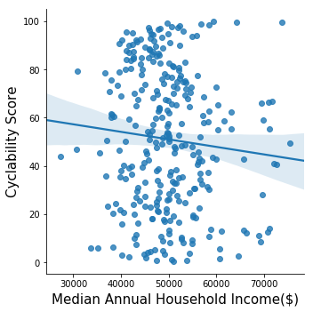

```python
plt.rcParams["axes.labelsize"] = 15
plot1 = seab.lmplot(x='median_annual_household_income',y='Cyclability score',data=final_dataframe_censusdata,fit_reg=True)
plot1.set(xlabel='Median Annual Household Income($)', ylabel='Cyclability Score')
print("Correlation coefficient for Cyclability score vs Median Annual Household Income")
final_dataframe_censusdata["Cyclability score"].corr(final_dataframe_censusdata["median_annual_household_income"])
```

Scatter Plot between cyclability score and average monthly rent per neighbourhood with Correlation coefficient and line of best fit. Written by Demitri Hahlos

```
Correlation coefficient for Cyclability score vs Average Monthly Rent
```

```
-0.14450167240710785
```

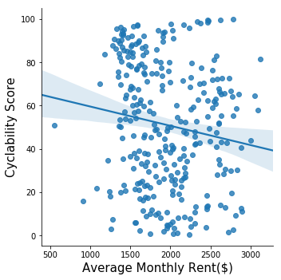

```python
plt.rcParams["axes.labelsize"] = 15
plot2 = seab.lmplot(x='avg_monthly_rent',y='Cyclability score',data=final_dataframe_censusdata,fit_reg=True)
plot2.set(xlabel='Average Monthly Rent($)', ylabel='Cyclability Score')
print("Correlation coefficient for Cyclability score vs Average Monthly Rent")
final_dataframe_censusdata["Cyclability score"].corr(final_dataframe_censusdata["avg_monthly_rent"])
```

## Residual plots

It is often useful to create a residual plot to determine how appropriate a linear model is. Fortunately, there are no clear patterns that emerge.

```
[Text(0, 0.5, 'Cyclability Score'), Text(0.5, 0, 'Average Monthly Rent($)')]
```

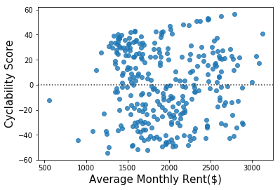

```python
plot3 = seab.residplot(x='avg_monthly_rent',y='Cyclability score',data=final_dataframe_censusdata)
plot3.set(xlabel='Average Monthly Rent($)', ylabel='Cyclability Score')
```

[output not shown]

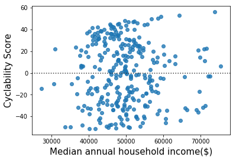

```python
plot4 = seab.residplot(x='median_annual_household_income',y='Cyclability score',data=final_dataframe_censusdata)
plot4.set(xlabel='Median annual household income($)', ylabel='Cyclability Score')
```

# Data examination

Plotting it on the map. First step is to do an attribute join of cylcability score and SA2 areas. Then I plot it.

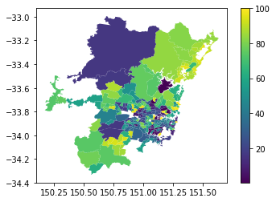

```python
sa2_cyclability = sa2_areas.merge(final_dataframe_censusdata, on="SA2_MAIN16")
sa2_cyclability.plot(column = "Cyclability score", legend=True)
```

# Futher work

Even after this is done, a few things are still needed before the assignment is complete.

- Create at least one geo-spatial index.
- Store extra data in database.
- Store cyclability table in database.
- Documentation

# Appendix: Geo-spatial join attempt

This was Nikki Zhang's attempt at a geo-spatial join. Unfortunately, it wasn't working.

```python
#bikepod density
#divided by area? what is the area?
import shapefile
sf = shapefile.Reader("Data/pyshp/SA2_2016_AUST.shp", encoding="iso-8859-1")
print(sf)

if (sf.shapeType == shapefile.POLYGON):
    shapes = sf.shapes()
    print("#shapes: ",len(shapes))
    for shape in shapes:
       print(shape.__geo_interface__['type'], len(shape.points), "points; bounding box:", shape.bbox)

sf.fields[1:]

for i in range(0, 10):
    print(sf.record(i))

SA2_schema = """DROP TABLE IF EXISTS World;
                CREATE TABLE IF NOT EXISTS World(
                    SA2_MAIN16 NUMERIC PRIMARY KEY,
                    SA2_NAME16 TEXT,
                    geom GEOMETRY(Polygon,4326))"""


pgquery(conn, "DROP TABLE World", msg="cleared old table")
pgquery(conn, SA2_schema, msg="created World table")

import re
insert_stmt="""INSERT INTO World VALUES (%(SA2_MAIN16)s,%(SA2_NAME16)s,ST_GEOMFROMTEXT(%(geom)s,4326))"""

shapes = sf.shapes()
records= sf.records()
print(len(shapes))
row = {}
try:
    for i in range(0, len(shapes)):
        record = sf.record(i)
        shape  = sf.shape(i)
        row['SA2_MAIN16']=record[0]
        row['SA2_NAME16']=record[2]

    # prepare the polygon data
    # this is a bit complex with our dataset as it has complex polygons, some with multiple parts...
        row['geom']="POLYGON(("
        i=0
        for x, y in shape.points:
           row['geom']+="%s %s," % (x,y)
           # check for start of a new polygon part
           i += 1
        row['geom'] = re.sub(",$", "))", row['geom'])
        pgquery(conn, insert_stmt, args=row, msg="inserted "+str(record[2]))

except:
    pass

query = "SELECT COUNT(*) FROM World"
result= pgquery(conn, query, returntype='dict')
from pprint import pprint
print(result)

query = """SELECT SA2_NAME16,SA2_MAIN16, ST_Area(geom) AS area
             FROM World
            LIMIT 5"""
result_world= pgquery(conn, query, returntype='dict')
pprint(result_world)

query = "SELECT ST_MakePoint(latitude,longitude) FROM BikeSharingPods"
result_bike= pgquery(conn, query, returntype='dict')
pprint(result_bike)
```